# Источники

- [Ивченко Г. И., Медведев Ю. И. “Математическая статистика”, изд. “Высшая школа”, 1984](https://www.hse.ru/pubs/share/direct/content_document/103185710)
- [Кибзун А. И., Наумов А. В., Горяинова Е. Р. “Теория вероятностей и математическая статистика. Базовый курс с примерами и задачами”, изд “ФИЗМАТЛИТ”, 2013](https://ami.nstu.ru/~post/teaching/tv_ms/kibzun.pdf)
- [Панков А. Р., Платонов Е. Н. “Практикум по математической статистике”, изд. “МАИ”, 2006](http://zyurvas.narod.ru/knyhy2/Pankov_matstat.pdf)

# Многомерное нормальное распределение

## Замечание

Вектор $X = (X_{1}, \dots, X_{n})^{T}$ называется *случайным*, если $X_{1}, \dots, X_{n}$ — *случайные величины* (далее **с.в**), определенные на одном вероятностном пространстве.

Через $M[X] = m_{X}$ обозначим *вектор математического ожидания*:

$$\begin{align*}
M[X] = m_{X} =
\begin{pmatrix}
M[X_1] \\
\vdots \\
M[X_n]
\end{pmatrix}
\end{align*}$$

Через $K_x$ обозначим *ковариационную матрицу* с.в $X$:

$$\begin{align*}
K_{X} =
\begin{pmatrix}
\mathrm{cov}(X_1, X_1) & \dots & \mathrm{cov}(X_1, X_n) \\
\vdots & \ddots & \vdots \\
\mathrm{cov}(X_n, X_1) & \dots & \mathrm{cov}(X_n, X_n) \\
\end{pmatrix}
\end{align*}$$

## Лемма 1

Пусть $K_{X} \in \mathbb{R}^{n \times n}$ — ковариационная матрица с.в $X$. Тогда:

1. $K_{X} \geqslant 0$, т.е. $\forall x \in \mathbb{R}^{n} \backslash \{0\}, x^{T}K_{X}x \geqslant 0$;
2. $K_{X}^{T} = K_{X}$

## Определение 1

Случайный вектор $X = (X_1, \dots, X_n)^{T}$ называется *невырожденным нормальным вектором*:

$$X \sim N(m_{X}, K_{X})$$

если совместная плотность вероятности имеет вид:

$$f_{X}(x) = ((2\pi)^{n} \det
K_{X})^{\frac{-1}{2}} \exp\{\frac{-1}{2}(x - m_{X})^{T}K_{X}^{-1}(x -
m_{X})\}$$

где $m_{X} \in \mathbb{R}^{n}, K_{X} \in \mathbb{R}^{n \times n}, K_{X} > 0, K_{X}^{T} = K_{X}$

## Лемма 2

Пусть $X$ — *невырожденный нормальный вектор* с параметрами $m_{X}$ и $K_{X}$.

Тогда $M[X] = m_{X}$, а $K_{X}$ — ковариационная матрица $X$.

Рассмотрим основные свойства многомерного нормального распределения.

## Лемма 3

Пусть $X \sim N(m_{X}, K_{X}), A \in \mathbb{R}^{m \times n}, b \in \mathbb{R}^{m}$.

Тогда:

$$\begin{align*}
Y = AX + b \sim N(m_Y, K_Y), \\
m_Y = Am_X + b, \\
K_Y = AK_XA^{T}.
\end{align*}$$

## Лемма 4

Пусть $X \sim N(m_{X}, K_{X})$.

Тогда компоненты вектора $X$ *независимы* тогда и только тогда, когда они *некоррелированы*.

## Замечание

Доказательство данных утверждений при помощи аппарата функций распределения и плотности довольно сложно. Поэтому рассмотрим аппарат характеристических функций.

## Определение 2

Пусть $X = (X_1, \dots, X_n)^{T}$ — случайный вектор.

Тогда *характеристической функцией* называется:

$$\psi_{X}(\lambda) = M[e^{i\lambda^{T}X}]
= \int\limits_{\mathbb{R}^{n}}e^{i\lambda^{T}X}dF_X(x)$$

## Замечание

*Характеристическая функция* определена для любого случайного вектора или с.в.

Если с.в **дискретная**, то:

$$\psi_{X}(\lambda) = \sum\limits_{k =
1}^{\infty}e^{i\lambda X_{k}}p_{k}$$

Если с.в **абсолютно непрерывная**, то

$$\psi_{X}(\lambda) =
\int\limits_{\mathbb{R}}e^{i\lambda X}f_{X}(x)dx$$

В этом случае $\psi_{X}(\lambda)$ является *преобразованием Фурье $f_X$*.

Поскольку преобразование Фурье взаимно однозначно, а $f_X$ однозначно определяет распределение, то характеристическая функция $\psi_{X}(x)$ также однозначно определяет распределение с.в $X$.

Причем:

$$f_{X}(x) = \frac{1}{(2\pi)^{n}}
\int\limits_{\mathbb{R}^{n}}e^{-i\lambda^{T}
X}\psi_{X}(\lambda)d\lambda$$

## Лемма 5

Пусть $X$ — случайный вектор, $A \in \mathbb{R}^{n \times n}, b \in \mathbb{R}^{n}$.

Тогда:

1. для $Y = AX + b$
   $$\psi_{Y}(\lambda) = e^{i\lambda^{T}b}
   \psi_{X}(A^{T}\lambda)$$
2. компоненты вектора $X$ *независимы* тогда и только тогда, когда
   $$\psi_{Y}(\lambda) = \prod\limits_{k = 1}^{n}
   \psi_{X_k}(\lambda_k)$$

### Доказательство

1. $\psi_{Y}(\lambda) = M[e^{i\lambda^{T}Y}] = M[e^{i\lambda^{T} AX} e^{i\lambda^{T} b}] = e^{i\lambda^{T} b} M[e^{i(A^{T}\lambda)^{T} X}] = e^{i\lambda^{T} b} \psi_{X}(A^{T}\lambda)$
2. $\psi_{X}(\lambda) = \int\limits_{\mathbb{R}} \dots \int\limits_{\mathbb{R}} e^{i(\lambda_{1} x_{1} + \dots + \lambda_{n} x_{n})} f_{X}(x_1, \dots, x_n)dx_1 \cdot \dots \cdot dx_n \overset{\text{н/з}}{=} \int\limits_{\mathbb{R}} \dots \int\limits_{\mathbb{R}} e^{i\lambda_{1} x_{1}} \cdot \dots \cdot e^{i\lambda_{n} x_{n}} \cdot f_{X_{1}}(x) \cdot \dots \cdot f_{X_{n}}dx_1 \cdot \dots \cdot dx_n = \int\limits_{\mathbb{R}} e^{i\lambda_{1} x_{1}} f_{x_1}(x_1)dx_1 \cdot \dots \cdot \int\limits_{\mathbb{R}} e^{i\lambda_{n} x_{n}} f_{x_n}(x_n)dx_n= \prod\limits_{k = 1}^{n} \psi_{X_k}(\lambda_{k})$

$\blacksquare$

## Замечание

При помощи характеристической функции можно дать другое определение нормального распределения. В том числе для вырожденного $K_{X}$.

## Определение 3

Случайный вектор $X$ называется *нормальным*: $X \sim N(m_{X}, K_{X})$, если:

$$\psi_{X}(\lambda) = \exp\{i\lambda^{T}
m_{X} - \frac{1}{2} \lambda^{T} K_{X}\lambda \}$$

### Доказательство леммы 3

В силу Леммы 5, п.1

$$\begin{align*}
\psi_{Y}(\lambda) = e^{i\lambda^{T}b} \psi_{X}(A^{T}\lambda) =
e^{i\lambda^{T}b} \exp\{i\lambda^{T} Am_x - \frac{1}{2} \lambda^{T}
AK_{X}A^{T}\lambda\} = \\
= \exp\{i\lambda^{T} \underbrace{(Am_x + b)}_{m_{Y}} -
\frac{1}{2}\lambda^{T} \underbrace{(AK_xA^{T})}_{K_{Y}}\lambda\} \\
\blacksquare
\end{align*}$$

### Доказательство леммы 4

Пусть $X_{i}, \dots, X_{n}$ *попарно некоррелированы*. Тогда $\mathrm{cov}(X_{i}, X_{j}) = 0$, $i \ne 0$, т.е. :

$$\begin{align*}
K_x = diag(\sigma_{X_1}^{2}, \dots, \sigma_{X_n}^{2}) = \\
=
\begin{pmatrix}
\sigma_{X_1}^{2} & \dots & 0 \\
\vdots & \ddots & \vdots \\
0 & \dots & \sigma_{X_n}^{2} \\
\end{pmatrix}
\end{align*}$$

$\psi_{X}(\lambda) = \exp\{i\lambda_{1} m_{X_1} + \dots + i\lambda_{n} m_{X_n} - \frac{1}{2} \lambda^{T} K_{X} \lambda \} = \exp\{i\lambda_{1} m_{X_1} + \dots + i\lambda_{n} m_{X_n} - \frac{1}{2}(\lambda_{1}^{2} \sigma_{X_1}^{2} + \dots + \lambda_{n}^{2} \sigma_{X_n}^{2})\} = \prod\limits_{k = 1}^{n} \exp\{i\lambda_{k} m_{X_k} - \frac{1}{2} \lambda_{k}^{2} \sigma_{K_k}^{2}\} = \prod\limits_{k = 1}^{n} \psi_{X_k} (\lambda_{k})$.

Откуда с учетом Леммы 5, п.1 $X_1, \dots, X_n$ — **н/з**.

Пусть $X_1, \dots, X_n$ — н/з. Тогда $X_1, \dots, X_n$ *попарно некоррелированы*. $\blacksquare$

## Замечание

Поскольку $K_{X}$ — невырожденная, симметрическая и положительноопределенная, то существует $S \in \mathbb{R}^{n \times n}$ — *ортогональная* (т. е. $S^{T} = S^{-1}$) такая, что:

$$S^{T}K_{X}S = \Lambda = diag(\lambda_1,
\dots, \lambda_n)$$

где $\lambda_{i} > 0, i = \overline{1, n}$

Определим матрицу $\Lambda^{- \frac{1}{2}} = diag(\lambda_{1}^{- \frac{1}{2}}, \dots, \lambda_{n}^{- \frac{1}{2}})$.

Рассмотрим вектор

$$Y = \Lambda^{- \frac{1}{2}} S^{T}(X -
m_{X})$$

Тогда $A = \Lambda^{- \frac{1}{2}}S^{T}, b = - \Lambda^{- \frac{1}{2}}S^{T}m_{X}$.

В силу Леммы 3:

$$m_{Y} = Am_{X} + b = \Lambda^{-
\frac{1}{2}}S^{T}m_{X} - \Lambda^{- \frac{1}{2}}S^{T}m_{X} = 0,$$
$$K_{Y} = AK_{X}A^{T} = \Lambda^{-
\frac{1}{2}}S^{T}K_{X}S\Lambda^{- \frac{1}{2}} = I,$$

т. е. $Y \sim N(0, I)$.

При помощи невырожденного линейного преобразования с.в. $X$ может быть преобразован в стандартный нормальный вектор.

Верно и обратное:

$$X = m_{X} + S\Lambda^{\frac{1}{2}}
Y,$$

откуда следует Лемма 2

# Теорема о нормальной корреляции

## Определение 1

*Условным математическим ожиданием абсолютно непрерывного случайного вектора* $X$ относительно абсолютно непрерывного случайного вектора $Y$ называется:

$$M[X \mid Y] = \int\limits_{- \infty}^{+
\infty} xf_{X | Y} (x \mid Y)dx,$$

где $f_{X \mid Y} (x \mid Y) = \frac{f_{z}(x, Y)}{f_{y}(Y)}, z = \begin{pmatrix} X \\ Y \\ \end{pmatrix}$

## Основные свойства условного М. О.

### Свойство 1

$M[C \mid Y] = \int\limits_{- \infty}^{+ \infty} Cf_{X \mid Y} (x \mid Y)dx = \frac{C \int\limits_{- \infty}^{+ \infty} f_{z}(x, Y)dx} {f_{Y}(Y)} = C \frac{f_{Y}(Y)}{f_{Y}(Y)} = C$. $\blacksquare$

### Свойство 2

$M[\varphi(Y) X \mid Y] = \int\limits_{- \infty}^{+ \infty} \varphi(Y)X f_{X \mid Y}(x \mid Y)dx = \varphi(Y) \int\limits_{- \infty}^{+ \infty} x f_{X \mid Y} (x \mid Y)dx =$

$= \varphi(Y) M[X \mid Y]$. $\blacksquare$

### Свойство 4

Пусть $X, Y$ — *независимые*. Тогда

$M[X \mid Y] = \int\limits_{- \infty}^{+ \infty} xf_{X \mid Y} (x \mid Y)dx = \int\limits_{- \infty}^{+ \infty} x \frac{f_{z}(x, Y)} {f_{Y}(Y)}dx = \int\limits_{- \infty}^{+ \infty}x \frac{f_{X}(x) f_{Y}(Y)}{f_{Y}(Y)} dx = M[X]$. $\blacksquare$

### Свойство 5

*(формула повторного М. О.)*

$M[M[X \mid Y]]= \int\limits_{- \infty}^{+ \infty} M[X \mid Y] f_{Y} (y)dy = \int\limits_{- \infty}^{+ \infty} f_{Y}(y) \int\limits_{- \infty}^{+ \infty} x f_{X \mid Y} (x \mid y)dxdy = \int\limits_{- \infty}^{+ \infty} \int\limits_{- \infty}^{+ \infty} x \frac{f_{Y}(y) f_{z}(x, y)}{f_{Y}(y)} dydx = \int\limits_{- \infty}^{+ \infty} x \int\limits_{- \infty}^{+ \infty} f_{z} (x, y)dydx = \int\limits_{- \infty}^{+ \infty} x f_{X}(x)dx = M[X]$. $\blacksquare$

## Лемма 1

Пусть $X, Y$ — случайные векторы с конечными вторыми моментами. Тогда:

$M[(X - \hat{X})\varphi(Y)^{T}] = 0$

где $\hat{X} = M[X \mid Y]$

### Доказательство

$M[(X - \hat{X})\varphi(Y)^{T}] = M[X \varphi(Y)^{T}] - M[M[X \mid Y] \varphi(Y)^{T}] =$

= по Свойству 2 $= M[X \varphi(Y)^{T}] - M[M[X \varphi(Y)^{T} \mid Y]] =$ по Свойству 5 $= M[X \varphi(Y)^{T}] - M[X \varphi(Y)^{T}] = 0$. $\blacksquare$

## Замечание

Если рассмотреть евклидово пространство $\mathbb{L}_{2}(\Omega)$ со скалярным произведением:

$$(X, Y) = M[X \cdot Y]$$

то *условное* М. О. — *оператор ортогонального проектирования* $X$ на подпространство, порождаемое $Y$.

## Определение 2

*Оценкой $X$ по наблюдениям $Y$* называется любая измеримая функция $\varphi(Y)$.

## Определение 3

*Оценка $\hat{X}$ называется с.к.-оптимальной оценкой $X$*, если для любой другой оценки $\tilde{X}$ верно

$$M[| X - \hat{X}|^{2}] \leqslant M[| X -
\tilde{X} |^{2}]$$

## Теорема 1

$M[X \mid Y]$ — *с.к.-оптимальная оценка $X$ по наблюдениям $Y$*.

### Доказательство

$M[|X - \tilde{X}|^{2}] = M[|X - \hat{X} + \hat{X} - \tilde{X}|^{2}] = M[|X - \hat{X}|^{2}] + 2M[(X - \hat{X})^{T} (\hat{X} - \tilde{X})] + M[|\hat{X} - \tilde{X}|^{2}] \overset{*}{=}$

Поскольку по определению $\tilde{X} - \hat{X} = \varphi(Y)$, то в силу Леммы 2.1 $M[(X - \hat{X})^{T}(\tilde{X} - \hat{X})] = 0$.

$\overset{*}{=} M[|X - \hat{X}|^{2}] + M[|\hat{X} - \tilde{X}|^{2}] \geqslant M[|X - \hat{X}|^{2}]$. $\blacksquare$

## Теорема 2 (О нормальной корреляции)

Пусть
$$\begin{align*}
\begin{pmatrix}
X \\
Y \\
\end{pmatrix}
\sim N
\begin{pmatrix}
\begin{pmatrix}
m_{X} \\
m_{Y} \\
\end{pmatrix},
\begin{pmatrix}
K_{X} & K_{XY} \\
K_{XY}^{T} & K_{Y} \\
\end{pmatrix}
\end{pmatrix}
\end{align*}$$

Тогда

1. $Law(X \mid Y) = N(\mu(Y), \Delta)$,

где

$$\mu(Y) = M[X \mid Y] = m_{X} +
K_{XY}K_{Y}^{-1}(Y - m_{Y})$$

$$\Delta = K_{X} -
K_{XY}K_{Y}^{-1}K_{YX}$$

2. $M[|X - \mu(Y)|^{2}] = tr(K_{X} - K_{XY}K_{Y}^{-1}K_{YX})$

### Доказательство

Рассмотрим линейное преобразование $Y$:

$$\mu(Y) = m_{X} + K_{XY}K_{Y}^{-1}(Y -
m_{Y})$$

В силу Леммы 1.3

$X - \mu(Y) = (I - K_{XY}K_{Y}^{-1}) \begin{pmatrix} X \\ Y \\ \end{pmatrix} - m_{X} + K_{XY}K_{Y}^{-1}m_{Y} \sim N(\mu, K)$

$\mu = (I - K_{XY}K_{Y}^{-1}) \begin{pmatrix} m_{X} \\ m_{Y} \\ \end{pmatrix} - m_{X} + K_{XY}K_{Y}^{-1}m_{Y} = 0$

$K = (I - K_{XY}K_{Y}^{-1}) \begin{pmatrix} K_{X} & K_{XY} \\ K_{XY}^{T} & K_{Y} \\ \end{pmatrix} \begin{pmatrix} I \\ -(K_{XY}K_{Y}^{-1})^{T} \\ \end{pmatrix} =$

$= \begin{pmatrix} K_{X} - K_{XY}K_{Y}^{-1}K_{XY}^{T} & K_{XY} - K_{XY}K_{Y}^{-1}K_{Y} \\ \end{pmatrix} \begin{pmatrix} I \\ K_{Y}^{-1}K_{XY}^{T} \\ \end{pmatrix} =$

$= K_{X} - K_{XY}K_{Y}^{-1}K_{XY}^{-1} = \Delta$

$\mathrm{cov}(X - \mu(Y), Y) = \mathrm{cov}(X, Y) - \mathrm{cov}(\mu(Y), Y) = \mathrm{cov}(X, Y) - \mathrm{cov}(K_{XY}K_{Y}^{-1}Y + m_{X} - K_{XY}K_{Y}^{-1}m_{Y}, Y) = \mathrm{cov}(X, Y) - K_{XY}K_{Y}^{-1}\mathrm{cov}(Y, Y) = K_{XY} - K_{XY}K_{Y}^{-2}K_{Y} = 0$

т.е. $X - \mu(Y)$ и $Y$ **некорреливаны**.

Тогда в силу Леммы 1.4, п.2 $X - \mu(Y)$ и $Y$ **независимы**. Построим характеристическую функцию условного распределения $X$ относительно $Y$:

$\psi_{X \mid Y}(\lambda \mid Y) = \int\limits_{\mathbb{R}^{n}} e^{i\lambda^{T} X} f_{X \mid Y}(x \mid Y)dx = M[e^{i\lambda^{T}X} \mid Y] = M[e^{i\lambda^{T}(X - \mu(Y))} e^{i\lambda^{T} \mu(Y)} \mid Y] \overset{*}{=}$

в силу Свойства 2 УМО и *независимости* $X - \mu(Y)$ и $Y$

$\overset{*}{=} M[e^{i\lambda^{T}(X - \mu(Y))} \mid Y] \cdot M[e^{i\lambda^{T}\mu(Y)} \mid Y] = M[e^{i\lambda^{T}(X - \mu(Y))}] e^{i\lambda^{T} \mu(Y)} = \psi_{X - \mu(Y)}(\lambda) e^{i\lambda^{T} \mu(Y)} = \exp\{- \frac{1}{2} \lambda^{T} \Delta \lambda \} \cdot \exp\{i\lambda^{T} \mu(Y) - \frac{1}{2} \lambda^{T} \Delta \lambda\}$

т.е. Условное распределение *нормальное*:

$$X(Y \sim N(\mu(Y), \Delta)$$

Вычислим с.к. ошибку:

$M[|X - \mu(Y)|^{2}] = M[\Delta X_{1}^{2} + \Delta X_{2}^{2} + \dots + \Delta X_{n}^{2}] = \sum\limits_{k = 1}^{n}M[\Delta X_{k}^{2}] = \sum\limits_{k = 1}^{n} D[\Delta X_{k}] = \sum\limits_{k = 1}^{n} \Delta_{kk} = tr\Delta$. $\blacksquare$

## Замечание

1. Из Теоремы о нормальной корреляции следует, что в *гауссовском* случае с.к.-оптимальная оценка является *линейной*.
2. Если $X$ и $Y$ — *независимы*, то с.к.-оптимальная оценка — $m_{X}$.
3. С.к.-оптимальная оценка *несмещенная*, т.к. $M[X - \mu(Y)] = 0$.

# Виды сходимости последовательностей случайных величин

## Определение 1

Говорят, что $\{X_{n}\}_{n = 1}^{\infty}$ образует *последовательность случайных величин*, если $\forall N \in \mathbb{N}$ $X_{n}$ определены на одном вероятностном пространстве.

## Определение 2

Говорят, что последовательность с.в. $\{X_{n}\}_{n \in \mathbb{N}}$ *сходится по вероятности* к с.в. $X$, если $\forall \varepsilon > 0$:

$$\lim\limits_{n \to \infty} P(|X_{n} - X|
\leqslant \varepsilon) = 1$$

ИЛИ

$$\lim\limits_{n \to \infty} P(|X_{n} - X|
> \varepsilon) = 0$$

## Определение 3

Говорят, что последовательность с.в. $\{X_{n}\}_{n \in \mathbb{N}}$ *сходится почти наверное* к с.в. $X$, если

$$P(\{\omega :X_{n}(\omega)
\cancel{\overset{n \to \infty}{\longrightarrow}} X(\omega)\}) =
0$$

ИЛИ

$$P(\{\omega :X_{n}(\omega) \overset{n \to
\infty}{\longrightarrow} X(\omega)\}) = 1$$

## Определение 4

Говорят, что последовательность с.в. $\{X\}_{n \in \mathbb{N}}$ *сходится в среднем квадратическом* к с.в. $X$, если

$$M[|X_{n} - X|^{2}] \overset{n \to
\infty}{\longrightarrow} 0$$

## Пример 1

Пусть $\{X_{n}\}_{n \in \mathbb{N}}$ — случайная последовательность.

$$X \sim
\begin{pmatrix}
0 & n \\
1 - \frac{1}{n^{2}} & \frac{1}{n^{2}} \\
\end{pmatrix}$$

$P(\{ \omega : \lim\limits_{n \to \infty} X_{n}(\omega) \neq 0 \}) = P(\{ \omega : \forall N \in \mathbb{N}, \exists n \geqslant N: X_{n}(\omega) = n \}) = P(\prod\limits_{N = 1}^{\infty} \sum\limits_{n = N}^{\infty} \{\omega : X_{n}(\omega) =n \}) \overset{*}{=}$

1. $\sum\limits_{n = N + 1}^{\infty}\{\omega : X_{n}(\omega) = n\} \subset \sum\limits_{n = N}^{\infty} \{\omega : X_{n}(\omega) = n\}$
2. $P(\sum\limits_{n = N}^{\infty} \{\omega : X_{n}(\omega) = n\}) \leqslant \sum\limits_{n = N}^{\infty} P(\{\omega : X_{n}(\omega) = n \}) = \sum\limits_{n = N}^{\infty} \frac{1}{n^2} \overset{n \to \infty}{\longrightarrow} 0$,

т.к. $\sum\limits_{n = 1}^{\infty} \frac{1}{n^2} < \infty$

Тогда в силу *аксиомы непрерывности* $\overset{*}{=} 0$, т.е. $X_{n} \overset{\text{п.н.}}{\longrightarrow} 0$

## Пример 2

Рассмотрим ту же последовательность. Выберем $\varepsilon > 0$

$$P(|X_{n} - 0| \leqslant \varepsilon) =
\begin{cases}
1, & \varepsilon \geqslant n \\
1 - \frac{1}{n^2}, & \varepsilon \in (0; n) \\
\end{cases} \overset{n \to \infty}{\longrightarrow} 1$$

Тогда $X_{n} \overset{P}{\longrightarrow} 0$

## Пример 3

Рассмотрим ту же последовательность:

$M[|X_{n} - 0|^{2}] = M[X_{n}^2] = 0^{2}(1 - \frac{1}{n^2}) + n^{2} \frac{1}{n^2} = 1 \cancel{\overset{n \to \infty}{\longrightarrow}} 0$

Тогда $X_{n} \cancel{\overset{\text{с.к.}}{\longrightarrow}} 0$

## Пример 4

Пусть $f_{nk}:[0;1] \longrightarrow \{0; 1\}, n \in \mathbb{N}, k = \overline{1, n}$,

$$f_{n, k} =
\begin{cases}
0, & t \notin [\frac{k - 1}{n}; \frac{k}{n}], \\
1, & t \in [\frac{k - 1}{n}; \frac{k}{n}]. \\
\end{cases}$$

Пусть $X \sim R(0; 1)$. Рассмотрим последовательность с.в. $X_{nk} = f_{nk}(X)$. $\forall \omega \in \Omega X(\omega) \in [0;1]$. Тогда $\forall n \in \mathbb{N}, \exists k = \overline{1, n}$ такое, что $X(\omega) \in [\frac{k - 1}{n}; \frac{k}{n}]$. Т.е. если $\varepsilon = \frac{1}{2}$, то $\forall n \in \mathbb{N}$ найдется $k = \overline{1, n}$ такой, что

$$|f_{nk}(X(\omega)) - 0| >
\varepsilon$$

Тогда $X_{nk}(\omega) \cancel{\overset{n \to \infty}{\longrightarrow}} 0$, т.е.

$$\{\omega : \lim\limits_{n,k \to \infty}
X_{nk}(\omega) = 0\} = \varnothing$$

$$X_{nk} \cancel{\overset{\text{п.
н.}}{\longrightarrow}} 0$$

При этом $\forall \varepsilon > 0$

$$R(|X_{nk} - 0| > \varepsilon) =
\begin{cases}
0, & \varepsilon \geqslant 1, \\
P(X \in [\frac{k - 1}{n}, & \frac{k}{n}]), \varepsilon \in (0;
1) \\
\end{cases} =
\begin{cases}
0, & \varepsilon \geqslant 1, \\
\frac{1}{n}, & \varepsilon \in (0; 1) \\
\end{cases} \overset{n \to \infty}{\longrightarrow} 0$$

$$X_{nk} \overset{P}{\longrightarrow}
0$$

$M[|X_{nk} - 0|^{2}] = M[X_{nk}] = M[f_{nk}(X)] = \int\limits_{0}^{1}f_{nk}(x) \underbrace{f_{X}(x)}_{1}dx = \int\limits_{0}^ {1} f_{nk}(x)dx = \int\limits_{\frac{k -1}{n}}^{\frac{k}{n}} 1 dx = \frac{1}{n} \overset{n \to \infty} {\longrightarrow} 0$

$$X_{nk}
\overset{\text{с.к}}{\longrightarrow} 0$$

## Пример 5

Рассмотрим последовательность с.в. $Y_{n_{1}k} = nK_{n_{1}k}$ Тогда $Y_{n_{1}k} \overset{\text{п.н.}} {\longrightarrow} 0$. $\forall \varepsilon > 0$.

$P(|Y_{n_{1}k} - 0| > \varepsilon) = \begin{cases} 0, & \varepsilon \geqslant n, \\ P(X \in [\frac{k -1}{n}; \frac{k}{n}]), & \varepsilon \in (0; n) \\ \end{cases} = \begin{cases} 0, & \varepsilon \geqslant n, \\ \frac{1}{n}, & \varepsilon \in (0; n) \\ \end{cases} \overset{n \to \infty}{\longrightarrow} 0$

$$Y_{n_{1}k} \overset{P}{\longrightarrow}
0$$

$M[|Y_{n_{1}k} - 0|^{2}] = M[n^{2} X_{nk}^{2}] = n^{2}M[X_{nk}] = n \overset{P}{\longrightarrow} \infty$

$$Y_{n_{1}k}
\cancel{\overset{\text{с.к}}{\longrightarrow}} 0$$

## Замечание

Согласно определению для исследования на сходимость нужно знать совместное распределение с.в. $X_{n}$ и $X$, а для случая *сходимости почти наверное* совместное распределение всей последовательности $\{X_{n}\}_{n \in \mathbb{N}}$ и $X$. Поэтому исследование на сходимость иначе, чем к детерминированной константе, довольно проблематично.

## Лемма 1

Пусть $X_{n} \overset{\text{п.н.}}{\longrightarrow} X$. Тогда $X_{n} \overset{P}{\longrightarrow} X$.

### Доказательство

$0 = P(\{\omega : \lim\limits_{n \to \infty} X_{n}(\omega) \neq X(\omega)\}) = P(\{\omega : \exists \varepsilon > 0 \forall N \in \mathbb{N}\exists n \geqslant N : |X_{n}(\omega) - X(\omega)| > \varepsilon\}) = P(\sum\limits_{\varepsilon > 0} \prod\limits_{N = 1}^{\infty} \sum\limits_{n = N}^{\infty} \{ \omega : |X_{n}(\omega) - X(\omega)| > \varepsilon \}) \geqslant P(\prod\limits_{N = 1}^{\infty} \sum\limits_{n = N}^{\infty} \{\omega : |X_{n}(\omega) - X(\omega)| > \varepsilon '\})$, $\forall \varepsilon ' > 0$

Тогда $0 = P(\prod\limits_{N = 1}^{\infty} \sum\limits_{n = N}^{\infty} \{\omega : |X_{n}(\omega) - X(\omega)| > \varepsilon\})$,

$$\sum\limits_{n = N + 1}^{\infty}
\{\omega : |X_{n}(\omega) - X(\omega)| > \varepsilon\} \subset
\sum\limits_{n = N}^{\infty} \{\omega : |X_{n}(\omega) - X(\omega)| >
\varepsilon\}$$

В силу *аксиомы непрерывности*:

$0 = \lim\limits_{N \to \infty} P(\sum\limits_{n = N}^{\infty} \{\omega : |X_{n}(\omega) - X(\omega)| > \varepsilon\}) \geqslant \lim\limits_{N \to \infty} P(\{\omega : |X_{N}(\omega) - X(\omega)| > \varepsilon\})$

$$X_{N} \overset{P}{\longrightarrow}
X$$
$\blacksquare$

## Лемма 2 (Неравенство Маркова)

Пусть $P(X \geqslant 0) = 1$, $M[X] < \infty$. Тогда $\forall \varepsilon > 0$

$$P(X > \varepsilon) \leqslant
\frac{M[X]}{\varepsilon}$$

### Доказательство

$M[X] = \int\limits_{0}^{+ \infty} xdF_{X}(x) \geqslant \int\limits_{\varepsilon}^{+ \infty} xdF_{X}(x) \geqslant \varepsilon \int\limits_{\varepsilon}^{+ \infty} dF_{X}(x) = \varepsilon P(X > \varepsilon)$. $\blacksquare$

## Следствие 1

Пусть $M[X^{k}] < \infty$. Тогда $\forall \varepsilon > 0$:

$$P(|X| > \varepsilon) \leqslant
\frac{M[|X|^{k}|]}{\varepsilon^{k}}$$

### Доказательство

$P(|X| > \varepsilon) = P(|X|^{k} > \varepsilon^{k}) \leqslant \frac{M[|X|^{k}]}{\varepsilon^{k}}$. $\blacksquare$

## Следствие 2 (Неравенство Чебышёва)

Пусть $M[X^{2}] < \infty$. Тогда

$$P(|X - M[X]| > \varepsilon) \leqslant
\frac{D[X]}{\varepsilon^{2}}$$

### Доказательство

$P(|X - M[X]| > \varepsilon) \leqslant \frac{M[|X - M[X]|^{2}]}{\varepsilon^{2}} = \frac{D[X]} {\varepsilon^{2}}$. $\blacksquare$

## Лемма 3

Пусть $X_{n} \overset{\text{с.к.}}{\longrightarrow} X$. Тогда $X_{n} \overset{P}{\longrightarrow} X$.

### Доказательство

$P(|X_{n} - X| > \varepsilon) \leqslant \frac{M[|X_{n} - X|^{2}]}{\varepsilon^{2}} \overset{n \to \infty}{\longrightarrow} 0$. $\blacksquare$

## Теорема 1 (Бореля — Кантелли)

Пусть $A_{1}, \dots, A_{n} \subset \Omega, B = \prod\limits_{N = 1}^{\infty} \sum\limits_{n = N}^{\infty} A_{n}$. Тогда

1. Если $\sum\limits_{n = 1}^{\infty} P(A_{n}) < \infty$, то $P(B) = 0$;
2. Если $A_{1}, \dots, A_{n}$ **независимы в совокупности** и $\sum\limits_{n = 1}^{\infty} P(A_{n}) = \infty$ , то $P(B) = 1$.

### Доказательство

1. $P(B) = P(\prod\limits_{N = 1}^{\infty} \sum\limits_{n = N}^{\infty} A_{n}) \overset{*}{=}$

т.к. $\sum\limits_{n = N + 1}^{\infty} A_{n} \subset \sum\limits_{n = N}^{\infty} A_{n}$, то *по аксиоме непрерывности* $\overset{*}{=} \lim\limits_{N \to \infty} P(\sum\limits_{n = N}^{\infty} A_{n}) \leqslant \lim\limits_{N \to \infty} \sum\limits_{n = N}^{\infty} P(A_{n}) = 0$, т.к. $\sum\limits_{n = 1}^{\infty} P(A_{n}) < \infty$

2. $P(B) = \dots = \lim\limits_{N \to \infty} P(\sum\limits_{n = N}^{\infty} A_{n}) = \lim\limits_{N \to \infty} (1 - P(\prod\limits_{n = N}^{\infty} \overline{A}_{n})) = 1 - \lim\limits_{N \to \infty} P(\prod\limits_{M = N}^{\infty} \prod\limits_{n = N}^{M} \overline{A}_{n}) \overset{*}{=}$

т.к. $\prod\limits_{n = N}^{M + 1} \overline{A}_{n} \subset \prod\limits_{n = N}^{M} \overline{A}_{n}$, то по *аксиоме непрерывности*

$\overset{*}{=} 1 - \lim\limits_{N \to \infty} \lim\limits_{M \to \infty} P(\prod\limits_{n = N}^{M} \overline{A}_{n}) = 1 - \lim\limits_{N \to \infty} \lim\limits_{M \to \infty} \prod\limits_{n = N}^{M} (1 - P(A_{n})) = 1 - \lim\limits_{N \to \infty} \lim\limits_{M \to \infty} \prod\limits_{n = N}^{M} e^{\ln(1 - P(A_{n}))} = 1 - \lim\limits_{N \to \infty} \lim\limits_{M \to \infty} e^{\sum\limits{n = N}^{M} \ln(1 - P(A_{n}))} \overset{*}{\geqslant}$

т.к. $\ln(1 - t) = -t - \frac{t^{2}}{2} - \frac{t^{3}}{3} - \frac{t^{4}}{4} - \dots < -t$, то

$\overset{*}{\geqslant} 1 - \lim\limits_{N \to \infty} \lim\limits_{M \to \infty} e^{- \sum\limits_{n = N}^{M} P(A_{n})} = 1 - \lim\limits_{n \to \infty} 0 = 1$. $\blacksquare$

## Лемма 4

Пусть $X_{n} \overset{P}{\longrightarrow} X$,

$$\sum\limits_{n = 1}^{\infty} P(|X_{n} -
X| > \varepsilon) < \infty$$
Тогда $X_{n} \overset{\text{п.н.}}{\longrightarrow} X$

### Доказательство

В силу Теоремы 3.1 $\forall \varepsilon > 0$

$$P(\prod\limits_{N = 1}^{\infty}
\sum\limits_{n = N}^{\infty} \{\omega : |X_{n} - X| > \varepsilon \})
= 0$$

Тогда

$P(\{\omega : \lim\limits_{n \to \infty} X_{n} X_{n}(\omega) \neq X(\omega)\}) = P(\{\omega : \exists \varepsilon > 0, \forall N \in \mathbb{N}\exists n \geqslant N : |X_{n}(\omega) - X(\omega)|> \varepsilon \}) = P(\{\omega : \exists M \in \mathbb{N}, \forall N \in \mathbb{N}\exists n \geqslant N : |X_{n}(\omega) - X(\omega)|> \frac{1}{M}\}) = P(\sum\limits_{M = 1}^{\infty} \prod\limits_{N = 1}^{\infty} \sum\limits_{n = N}^{\infty} \{ \omega : |X_{n} - X| > \frac{1}{M} \}) \leqslant \sum\limits_{M = 1}^{\infty} P(\prod\limits_{N = 1}^{\infty} \sum\limits{n = N}^{\infty} \{ \omega : |X_{n} - X| > \frac{1}{M} \}) = 0$. $\blacksquare$

## Замечание

$X_{n} \overset{\text{с.к.}}{\longrightarrow} X \implies X_{n} \overset{P}{\longrightarrow} X$

ИЛИ

$X_{n} \overset{\text{п.н.}}{\longrightarrow} X \implies X_{n} \overset{P}{\longrightarrow} X$

2. В силу *теоремы Рисса* (функциональный анализ) если $X_{n} \overset{P}{\longrightarrow} X$, то существует *подпоследовательность* $\{X_{n_{k}}\}_{k \in \mathbb{N}} : X_{n_{k}} \underset{k \to \infty}{\overset{\text{п.н.}}{\longrightarrow}} X$
3. В силу *теоремы о мажорирующей сходимости*, если $X_{n} \overset{P}{\longrightarrow} X$ и $\exists Y$ — с.в.: $|X_{n}| \leqslant Y, M[Y^{2}] < \infty$, то $X_{n} \overset{\text{с.к.}}{\longrightarrow} X$
4. Также из функционального анализа известно, что операция предела (по мере, почти наверное, в средне квадратическом) замкнута относительно линейных операций и непрерывных преобразований.

# Закон больших чисел

## Определение 1

*Выборкой* объема $n$ будем называть с.в. $Z_{n} = (X_{1}, \dots, X_{n})^{T}$, где $X_{1}, \dots, X_{n}$ — *независимые* с.в.

Через $F_{k}(x)$ обозначим *функцию распределения* k-го элемента выборки.

Если $F_{k} = F_{1}, k = \overline{2, n}$, то выборка называется *однородной*.

## Определение 2

*Выборочным средним* $\overline{X}_{n}$ выборки $Z_{n}$ называется $\overline{X}_{n} = \frac{1}{n} \sum\limits_{k = 1}^{n} X_{k}$

## Теорема 1 (Закон Больших Чисел Чебышёва)

Пусть $Z_{n}$ — однородная выборка, $M[X_{k}^{2}] < \infty$.

Тогда $\overline{X}_{n} \overset{\text{с.к.}}{\longrightarrow} m_{X}, \overline{X}_{n} \overset{P}{\longrightarrow} m_{X}$

### Доказательство

$M[|\overline{X}_{n} - m_{X}|^{2}] = M[|\overline{X}_{n} - M[\overline{X}_{n}]|^{2}] = D[\overline{X}_{n}] = \frac{1}{n^{2}} D[\sum\limits_{k = 1}^{n} X_{k}] = \frac{n D[X_{1}]}{n^{2}} \overset{n \to \infty}{\longrightarrow} 0$

Т.е. по определению $\overline{X}_{n} \overset{\text{с.к.}}{\longrightarrow} m_{X}$.

С учетом Леммы 3.3 $\overline{X}_{n} \overset{P}{\longrightarrow} m_{X}$. $\blacksquare$

## Теорема 2 (Закон Больших Чисел Колмогорова)

Пусть $Z_{n}$ — *однородная* выборка, $M[X_{k}] = m_{X} < \infty$.

Тогда $\overline{X}_{n} \overset{\text{п.н.}}{\longrightarrow} m_{X}$

## Теорема 3

Пусть $Z_{n}$ — *неоднородная* выборка, $M[X_{k}] = m_{X} < \infty, D[X_{k}] = D_{k} \leqslant D_{max} < \infty$, где $k \in \mathbb{N}$

Тогда $\overline{X}_{n} \overset{\text{с.к.}}{\longrightarrow} m_{X}, \overline{X}_{n} \overset{P}{\longrightarrow} m_{X}$.

### Доказательство

$M[|\overline{X}_{n} - m_{X}|^{2}] = M[|\overline{X}_{n} - M[\overline{X}_{n}]|^{2}] = D[X_{n}] = \frac{1}{n^{2}} \sum\limits_{k = 1}^{n} D_{k} \leqslant \frac{n D_{max}}{n^{2}} = \frac{D_{max}}{n} \overset{n \to \infty}{\longrightarrow} 0$

Т.о. $\overline{X}_{n} \overset{\text{с.к.}}{\longrightarrow} m_{X}$. Тогда в силу Леммы 3.3 $\overline{X}_{n} \overset{P}{\longrightarrow} m_{X}$. $\blacksquare$

## Следствие 1

Пусть $Z_{n}$ — *неоднородная* выборка, $D[X_{k}] = D_{k} \leqslant D_{max} < \infty, k \in \mathbb{N}$.

Тогда $\overline{X}_{n} - \frac{1}{n} \sum\limits_{k = 1}^{n} m_{X_{k}} \overset{\text{с.к.}}{\longrightarrow} 0, \overline{X}_{n} - \frac{1}{n} \sum\limits_{k = 1}^{n} m_{X_{k}} \overset{P}{\longrightarrow} 0$.

### Доказательство

$\overline{X}_{n} - \frac{1}{n} \sum\limits_{k = 1}^{n} m_{X_{k}} = \frac{1}{n} \sum\limits_{k = 1}^{n} (X_{k} - m_{X_{k}}) = \frac{1}{n} \sum\limits_{k = 1}^{n} Y_{k}$, где $M[Y_{k}] = 0, D[Y_{k}] = D[X_{k}] \leqslant D_{max} < \infty$

Тогда $\overline{Y}_{k}$ удовлетворяет условиям Теоремы 4.3. $\blacksquare$

## Теорема 4

Пусть $Z_{n}$ — *неоднородная* выборка, $M[X_{k}] = m_{X} < \infty, D[X_{k}] = D_{k} < \infty$,

$$\sum\limits_{k = 1}^{n}
\frac{D[X_{k}]}{k^{2}} < \infty$$

Тогда

$$\overline{X}_{n}
\overset{\text{п.н.}}{\longrightarrow} m_{X}$$

## Замечание

Условие Теоремы 4 более мягкое, чем условие Теоремы 3. Пусть $D[X_{k}] \leqslant D_{max}, k \in \mathbb{N}$. Тогда

$$\sum\limits_{k = 1}^{n}
\frac{D[X_{k}]}{k^{2}} \leqslant \sum\limits_{k = 1}^{n}
\frac{D_{max}}{k^{2}} =
\frac{\pi^{2} D_{max}}{\sigma} < \infty$$

## Следствие 2

Пусть $N(A)$ — число появления события $A$ в серии из $N$ *независимых* опытов. Тогда

$$\frac{N(A)}{N}
\overset{\text{п.н.}}{\longrightarrow} P(A), \frac{N(A)}{N}
\overset{\text{с.к.}}{\longrightarrow} P(A)$$

### Доказательство

По условию $N(A) \sim Bi(N; P(A))$. Тогда $\exists X_{1}, \dots, X_{n} \sim Be(P(A))$ — независимые с.в.

При этом $M[X_{1}] = P(A), D[X_{1}] = P(A)(1 - P(A)) \leqslant \frac{1}{4}$.

$$\frac{N(A)}{N} = \frac{1}{N}
\sum\limits_{k = 1}^{N} X_{k} \overset{\text{с.к.}}{\longrightarrow}
P(A)$$

в силу Теоремы 2

$$\frac{N(A)}{N} = \frac{1}{N}
\sum\limits_{k = 1}^{N} X_{k}
\overset{\text{п.н.}}{\longrightarrow} P(A)$$

$\blacksquare$

# Центральная предельная теорема (ЦПТ)

## Замечание

Сходимости *с.к.*, *п.н.* и *$P$* в общем случае исследования предполагают либо знание совместного распределения элементов последовательности, либо наличие точкой функциональной зависимости от $\omega \in \Omega$.

Как правило, в теории вероятностей это неизвестно, а с.в. описываются при помощи их распределений, а не как функции. При этом если у двух величин совпадают распределения, то это вовсе не значит, что они равны.

Поэтому довольно важным является вид сходимости *по распределению*, т.е. в смысле “описательного инструмента” с.в.

## Определение 1

Говорят, что последовательность с.в. $\{X_{n}\}_{n \in \mathbb{N}}$ *сходится по распределению* к с.в. $X$, если

$F_{X_{n}}(x) \overset{n \to \infty}{\longrightarrow} F_{X}(x)$, $\forall x$ — точки непрерывности $F_{X}(x)$.

## Лемма 1

Пусть $X_{n} \overset{P}{\longrightarrow} X$. Тогда $X_{n} \overset{d}{\longrightarrow} X$

## Лемма 2

Пусть $X_{n} \overset{d}{\longrightarrow} X$, $Y_{n} \overset{P}{\longrightarrow} C$

Тогда $X_{n} + Y_{n} \overset{d}{\longrightarrow} X + C$

### Доказательство

Пусть $C = 0$, $x_{0}$ — точка **непрерывности** $F_{X}(x)$. Тогда $\forall \varepsilon > 0$

$F_{X_{n} + Y_{n}}(x_{0}) = P(X_{n} + Y_{n} \leqslant x_{0}) = \underbrace{P(\{X_{n} + Y_{n} \leqslant x_{0}\} \{|Y_{n}| > \varepsilon\})}_{p_{1}} + \underbrace{P(\{X_{n} + Y_{n} \leqslant x_{0}\} \{|Y_{n}| \leqslant \varepsilon\})}_{p_{2}}$

$$0 \leqslant p_{1} \leqslant P(|Y_{n}|
> \varepsilon) \overset{n \to \infty}{\longrightarrow} 0$$

$p_{2} = P(\{X_{n} + Y_{n} \leqslant x_{0}\} \{- \varepsilon \leqslant Y_{n} \leqslant \varepsilon\}) \overset{*}{\leqslant}$

$$\begin{cases}
X_{n} + Y_{n} \leqslant x_{0} \\
- \varepsilon \leqslant Y_{n} \leqslant \varepsilon \\
\end{cases} \implies
\begin{cases}
X_{n} + Y_{n} \leqslant x_{0} \\
- \varepsilon \leqslant - Y_{n} \leqslant \varepsilon \\
\end{cases} \implies X_{n} \leqslant x_{0} + \varepsilon$$

$\overset{*}{\leqslant} P(X_{n} \leqslant x_{0} + \varepsilon) = F_{X_{n}} (x_{0} + \varepsilon)$

$p_{2} \geqslant P(\{\varepsilon + X_{n} \leqslant x_{0}\} \{- \varepsilon \leqslant Y_{n} \leqslant \varepsilon \}) \overset{*}{\geqslant}$

$$P(AB) = P(A) - P(A \backslash B)
\geqslant P(A) - P(\overline{B})$$

$\overset{*}{\geqslant} P(\varepsilon + X_{n} \leqslant x_{0}) - P(|Y_{n} > \varepsilon) = F_{X_{n}}(x_{0} - \varepsilon) - P(|Y_{n}| > \varepsilon)$

Т.о. $F_{X_{n}}(x_{0} - \varepsilon) - P(|Y_{n}| > \varepsilon) \leqslant F_{X_{n} + Y_{n}} (x_{0}) \leqslant F_{X_{n}} (x_{0} + \varepsilon) + p_{1}$

Выберем $\varepsilon > 0$ так, чтобы $(x_{0} - \varepsilon; x_{0} + \varepsilon)$ было областью непрерывности $F_{X}(x)$

Тогда $\lim\limits_{n \to \infty} F_{X_{n}} (x_{0} \pm \varepsilon) = F_{X}(x_{0} \pm \varepsilon)$

$$F_{X_{n}} (x_{0} - \varepsilon)
\leqslant \lim\limits_{\overline{n \to \infty}} F_{X_{n} + Y_{n}}
(x_{0}) \leqslant \overline{\lim\limits_{n \to \infty}} F_{X_{n} +
Y_{n}} (x_{0}) \leqslant
F_{X}(x_{0} + \varepsilon)$$

Возьмем предел по $\varepsilon \to 0$. В силу непрерывности $F_{X}(x)$ в $x_{0}$ $\lim\limits_{\varepsilon \to 0} F_{X}(x_{0} \pm \varepsilon) = F_{X}(x_{0})$

Откуда $F_{X}(x_{0}) = \lim\limits_{\varepsilon \to 0} F_{X_{n} + Y_{n}}(x_{0})$, т.е.

$$X_{n} + Y_{n}
\overset{d}{\longrightarrow} X$$

Пусть $C \neq 0$. Тогда $Y_{n} - C = \tilde{Y} \overset{P}{\longrightarrow} 0$,

$X_{n} + C = \tilde{X}_{n} \overset{d}{\longrightarrow} X + C = \tilde{X}$

Получаем $X_{n} + Y_{n} = \tilde{X}_{n} + \tilde{Y}_{n} \overset{d}{\longrightarrow} \tilde{X} = X + C$. $\blacksquare$

## Доказательство леммы 5.1

$X_{n} = (X_{n} - X) + X$, где $X \overset{d}{\longrightarrow} X, X_{n} - X \overset{P}{\longrightarrow} 0$. В силу Леммы 5.2 $X_{n} = (X_{n} - X) + X \overset{d}{\longrightarrow} X + 0 = X$. $\blacksquare$

## Замечание

Из *теории преобразования Фурье* следует, что $X_{n} \overset{d}{\longrightarrow} X$ тогда и только тогда, когда $\psi_{X_{n}}(\lambda) \overset{n \to \infty}{\longrightarrow} \psi_{X}(\lambda), \lambda \in \mathbb{R}$

## Определение 2

Последовательность с.в. $\{X_{n}\}_{n \in \mathbb{N}}$ называется *асимптотически нормальной*, если

$X_{n} \overset{d}{\longrightarrow} X$, где $X \sim N(m; \sigma^{2})$

## Теорема 1 (Центральная предельная)

Пусть $\{X_{n}\}_{n \in \mathbb{N}}$ — последовательность *независимых* и *одинаково распределенных* с.в., причем

$$M[X_{1}] = m_{X}, D[X_{1}] =
\sigma_{X}^{2}$$

Тогда

$$S_{n} = \frac{\sum\limits_{k = 1}^{n}
X_{n} - nm_{X}}{\sigma_{X} \sqrt{n}} \overset{d}{\longrightarrow}
N(0; 1)$$

### Доказательство

Обозначим через $Y_{k} = \frac{X_{k} - m_{X}}{\sigma_{X} \sqrt{n}}$

Тогда $\sum\limits_{k = 1}^{n} Y_{k}$, где $Y_{1}, \dots, Y_{n}$ — *независимые* с.в.

В силу Леммы 1.5

$$\psi_{S_{n}} (\lambda) = \psi_{Y}
(\lambda, \lambda, \dots, \lambda) =
\prod\limits_{k = 1}^{n} \psi_{Y_{k}}(\lambda) =
\psi_{Y_{1}}^{n}(\lambda) = \psi^{n}
(\frac{\lambda}{\sigma_{X} \sqrt{n}})$$
где $\psi(\lambda)$ — **характеристическая функция** $X_{k} - m_{X}$.

$\psi(0) = M[e^{i0(X_{k} - m_{X})}] = M[1] = 1$

$\psi'(0) = M[i(X_{k} - m_{X})e^{i0(X_{k} - m_{X})}] = M[X_{k} - m_{X}] i = 0$

$\psi''(0) = - M[(X_{k} - m_{X})^{2} e^{i0(X_{k} - m_{X})}] = - M[(X_{k} - m_{X})^{2}] = - \sigma_{X}^{2}$

Тогда согласно *формуле Тейлора*

$\psi(\lambda) = \psi(0) + \psi'(0) \lambda + \psi''(0) \frac{\lambda^{2}}{2} + o(\lambda^{2}) = 1 - \frac{\sigma_{X}^{2}}{2} \lambda^{2} + o(\lambda^{2})$

Рассмотрим $\ln\psi_{S_{n}}(\lambda) = n \ln\psi(\frac{\lambda}{\sigma_{X} \sqrt{n}}) = n \ln(1 - \frac{\lambda^{2}}{2n} + o(\frac{\lambda^{2}}{\sigma_{X}^{2}n})) = n(- \frac{\lambda^{2}}{2n} + o(\frac{\lambda^{2}}{\sigma_{X}^{2}n}) + o(- \frac{\lambda^{2}}{2n} + o(\frac{\lambda^{2}}{\sigma_{X}^{2}n}))) = n(- \frac{\lambda^{2}}{2n} + o(\frac{\lambda^{2}}{2n})) = - \frac{\lambda^{2}}{2n} + \frac{o(\frac{\lambda^{2}}{\sigma_{X}^{2}n})}{\frac{\lambda^{2}}{\sigma_{X}^{2}n}} \cdot \frac{\lambda^{2}}{2} \overset{n \to \infty}{\longrightarrow} - \frac{\lambda^{2}}{2}$,

$$\psi_{S_{n}}(\lambda) \overset{n \to
\infty}{\longrightarrow} e^{- \frac{\lambda^{2}}{2}}$$

где $\psi_{Y}(\lambda) = e^{- \frac{\lambda^{2}}{2}}$ по определению является *характеристической функцией* $Y \sim N(0; 1)$

Тогда $S_{n} \overset{d}{\longrightarrow} Y \sim N(0; 1)$. $\blacksquare$

## Следствие 1 (Теорема Муавра - Лапласа)

Пусть $X_{n} \sim Bi(n; p)$

Тогда

$$\frac{X_{n} - np}{\sqrt{np(1 - p)}}
\overset{d}{\longrightarrow} N(0; 1)$$

### Доказательство

Т.к. $X_{n} \sim Bi(n; p)$, то существуют **независимые** $\tilde{X}_{1}, \dots, \tilde{X}_{n} \sim Be(p)$ такие, что

$$X_{n} = \sum\limits_{k = 1}^{n}
\tilde{X}_{k}, M[\tilde{X}_{k}] = p = m_{X}, D[\tilde{X}_{k}] =
p(1 - p) = \sigma_{X}^{2}$$

Тогда в силу Теоремы 1:

$\frac{\sum\limits_{k = 1}^{n} \tilde{X}_{k} - nm_{X}}{\sigma_{X}\sqrt{n}} \overset{d}{\longrightarrow} N(0; 1)$. $\blacksquare$

## Пример 1

Вычислить вероятность того, что при $n = 1000$ подбрасываниях монета упадет *“орлом”* от $400$ до $600$ раз.

Пусть $X$ — число выпавших *“орлов”*. Тогда $X \sim Bi(1000; \frac{1}{2})$. По *формуле Бернулли*

$$P(X \in [400; 600]) = \sum\limits_{k =
400}^{600} C_{1000}^{k} \frac{1}{2^{1000}}$$

Оценим данную величину с помощью *ЦПТ*.

В силу Теоремы 1 и Следствия

$$\frac{X - n \frac{1}{2}}{\sqrt{n
\frac{1}{2}(1 - \frac{1}{2})}} \overset{d}{\longrightarrow}
N(0; 1)$$

Тогда

$P(400 \leqslant X \leqslant 600) = P(\frac{400 - 500}{\sqrt{250}} \leqslant \frac{X - nm_{X}}{\sigma_{X}\sqrt{n}} \leqslant \frac{600 - 500}{\sqrt{250}}) \approx \Phi_{0}(\frac{100}{5\sqrt{10}}) - \Phi_{0}(- \frac{100}{5\sqrt{10}}) = 2 \Phi_{0}(2\sqrt{10}) \approx 1$.

## Теорема 2 (Ляпунова)

Пусть $\{X_{n}\}_{n \in \mathbb{N}}$ — последовательность *независимых* с.в., $M[X_{n}] = m_{X_{n}}, D[X_{n}] = \sigma_{X_{n}}^{2}, M[|X_{n} - m_{X_{n}}|^{3}] = C_{n}^{3} < \infty$

При этом $\frac{(\sum\limits_{k = 1}^{n} C_{k}^{3})^{\frac{1}{3}}}{ (\sum\limits_{k = 1}^{n} \sigma_{X_{k}}^{2})^{\frac{1}{2}}} \overset{n \to \infty}{\longrightarrow} 0$ *(Условие Ляпунова)*

Тогда $\frac{(\sum\limits_{k = 1}^{n} X_{k} - M[\sum\limits_{k = 1}^{n} X_{k}]}{ \sqrt{D[\sum\limits_{k = 1}^{n} X_{k}]}} \underset{n \to \infty}{\overset{d}{\longrightarrow}} \sim N(0; 1)$

## Замечание

Для *аппроксимации* точности использования ЦПТ используется **неравенство Берри-Эссеена**

## Теорема 3 (Неравенство Берри-Эссеена)

Пусть $\{X_{n}\}_{n \in \mathbb{N}}$ — последовательность *независимых* и *одинаково распределенных* с.в.

$$M[X_{n}] = m_{X}, D[X_{n}] =
\sigma_{X}^{2}, M[|X_{n} - m_{X}|^{3}] = \rho < \infty$$

Тогда $\forall x \in \mathbb{R}$ и $n \in \mathbb{N}$

$$|P(\frac{\sum\limits_{k = 1}^{n} X_{k} -
n m_{X}}{\sigma_{X}\sqrt{n}}) -
(\frac{1}{2} + \Phi_{0}(x))| \leqslant
\frac{C_{0}\rho}{\sigma_{X}^{3}\sqrt{n}}$$

## Замечание

Точное значение константы $C$ **неизвестно**.

По текущим данным *(2010 г.)* $C_{0} \leqslant 0.4784$

## Пример

Оценим точность решения в предыдущем примере: $\sigma_{X}^{2} = \frac{1}{4}, n = 1000, m_{X} = \frac{1}{2}, X_{n} \sim \begin{pmatrix} 0 & 1 \\ \frac{1}{2} & \frac{1}{2} \\ \end{pmatrix}$

$\rho = M[|X_{n} - m_{X}|^{3}] = |0 - \frac{1}{2}|^{3} \cdot \frac{1}{2} + |1 - \frac{1}{2}|^{3} \cdot \frac{1}{2} = \frac{1}{8}$

Тогда погрешность составит для двухстороннего нер-ва:

# Выборка и ее характеристики

## Определение 1

*Выборкой* называется $Z_{n} = (X_{1}, \dots, X_{n})^{T}$ *независимый вектор* с.в. Если все $X_{1}, \dots, X_{n}$ — *одинаково распределены*, а $F(x)$ — *функция распределения*, то говорят, что $Z_{n}$ — *однородная* выборка, порожденная распределением $F(x)$

## Определение 2

*Реализацией выборки* $Z_{n} \in \mathbb{R}^{n}$ называется *неслучайный* вектор $z_{n} = Z_{n}(\omega)$, состоящий из реализаций элементов выборки $X_{k}, k = \overline{1, n}$.

## Определение 3

Множество $S$ всех возможных реализаций выборки $Z_{n}$ называют *выборочным пространством*

## Замечание

Обычно распределение, порождающее выборку, известно неточно.

$$F_{X} = F_{X}(x; \theta)$$

Задача состоит в построении оценки $\theta$ по элементам выборки.

## Определение 4

С.в. $\varphi(Z_{n})$, где $\varphi : S \to \mathbb{R}$ — *измерима*, называется *статистикой*.

## Определение 5

*k-ой порядковой статистикой* называется k-е по величине значение элемента выборки $Z_{n} = (X_{1}, \dots, X_{n})^{T}$ и обозначается $X^{(k)}$

## Замечание

$X^{(k)}$ является функцией от всей выборки, т.к. при различных $\omega \in \Omega$ $X^{(k)}$ будет совпадать по значению с разными $X_{i}$.

## Определение 6

Набор порядковых статистик $X^{(1)}, \dots, X^{(n)}$ называется *вариационным рядом*.

## Определение 7

$X^{(1)} = \min_{k = \overline{1, n}} X_{k}, X^{(n)} = \max_{k = \overline{1, n}} X_{k}$.

## Лемма 1

Пусть однородная выборка $Z_{n}$ порождена распределением $F(x)$. Тогда функция распределения $X^{(k)}$ имеет вид:

$$F_{(k)}(x) = P(X^{(k)} \leqslant x) =
\sum\limits_{i = k}^{n} C_{n}^{i} (F(x))^{i}(1 - F(x))^{n -
i}$$

### Доказательство

Рассмотрим с.в. $Y$, равную числу элементов выборки, не превосходящих $x$. Тогда $Y \sim Bi(n; F(x))$.

$F_{(k)}(x) = P(X^{(k)} \leqslant x) = P(Y \geqslant k) = \sum\limits_{i = k}^{n} C_{n}^{i} (F(x))^{i}(1 - F(x))^{n - i}$. $\blacksquare$

## Следствие 1

$F_{(1)}(x) = 1 - (1 - F(x))^{n}$,

$F_{(n)}(x) = (F)^{n}$.

## Определение 8

*Выборочным квантилем* уровня $\alpha \in (0; 1)$ называется *порядковая статистика* $X^{([n\alpha] + 1)}$

## Теорема 1 (Мостеллера)

Пусть $X$ — *абсолютно непрерывная* с.в., $x_{\alpha}$ — *точка гладкости* $f_{X}(x), f_{X}(x_{\alpha}) > 0$

Тогда $(X^{([n\alpha] + 1)} - x_{\alpha}) \sqrt{\frac{n f_{X}^{2} (x_{\alpha})}{p(1 - p)}} \overset{d}{\longrightarrow} N(0; 1)$

## Определение 9

*Выборочной функцией распределения* называется статистика $\hat{F}_{n}(x)$:

$$\hat{F}_{n}(x) =
\begin{cases}
\frac{1}{n} \max\{k = \overline{1, n} : X^{(k)} \leqslant x\}, &
x \geqslant X^{(1)}, \\
0, & x < X^{(1)} \\
\end{cases}$$

## Замечание

Фактически $\hat{F}_{n}(x)$ — **частота события** $\{X \leqslant x\}$, которая используется для оценки вероятности $F(x) = P(X \leqslant x)$.

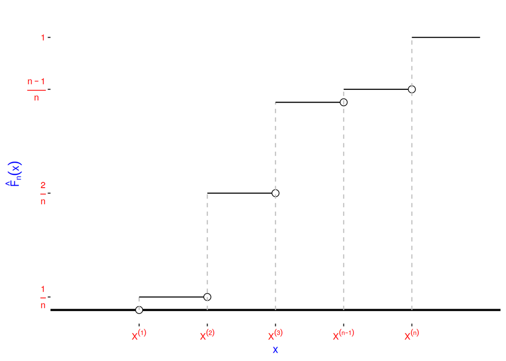

## Замечание

$t_{1} \leqslant x^{(1)}, t_{l} > x{(n)}$.

Как правило, длина интервалов разбиения выбирается *одинаковой*:

$$h_{k} = t_{k + 1} - t_{k} = \frac{t_{l}
- t_{1}}{l - 1}, k = \overline{1, l - 1}$$

Вычислим частоту попадания элементов выборки в k-й интервал:

$\hat{p}_{k} = \frac{n_{k}}{n}$, где $n_{k}$ — число элементов выборки, попавших в $[t_{k}; t_{k + 1}), k = \overline{0, l}$

Заметим, что $\hat{p}_{0} = \hat{p}_{l} = 0$.

## Определение 10

*Гистограммой* называется функция:

$$\hat{f}_{n}(x) =
\begin{cases}
0, & x \in (t_{0}; t_{1}) \cup [t_{l}; t_{l + 1}), \\
\hat{p}_{k}, & x \in (t_{k}; t_{k + 1}), k = \overline{1, l - 1}
\\
\end{cases}$$

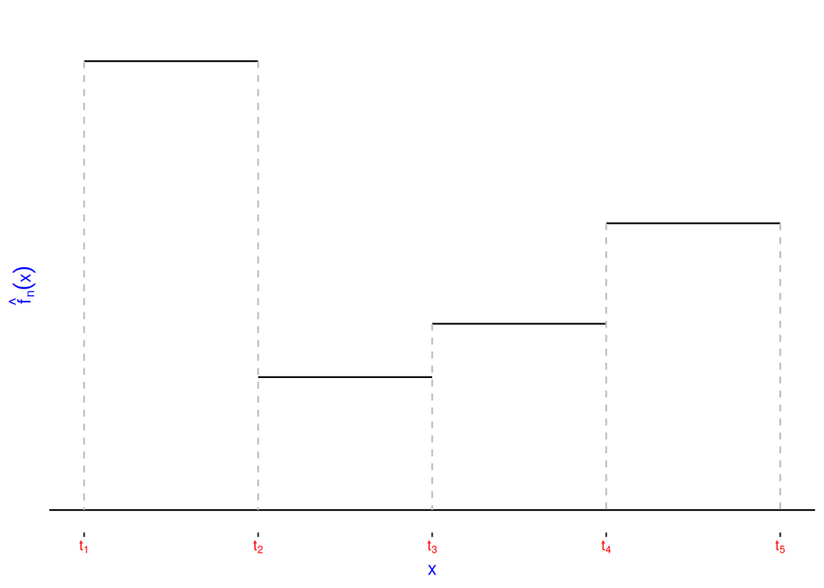

## Замечание

Если плотность вероятности $f_{X}(x)$ *непрерывна* и *ограничена*, а число разрядов гистограммы $l_{n}$ *удовлетворяет условию*: $l_{n} \longrightarrow + \infty, \frac{n}{l_{n}} \longrightarrow + \infty$,

то

$$\hat{f}_{n}(x)
\overset{P}{\longrightarrow} f_{X}(x)$$

Т.е. гистограмма является статистической аппроксимацией функции плотности вероятности.

## Определение 1

*Выборочным начальным* и *центральным моментами* называется соответственно статистики:

$\hat{\nu}_{r}(n) = \frac{1}{n} \sum\limits_{k = 1}^{n} X_{k}^{r}$

И

$\hat{\mu}_{r}(n) = \frac{1}{n} \sum\limits_{k = 1}^{n} (X_{k} - \hat{\nu}_{1}(n))^{r}$

## Определение 2

*Выборочным средним* и *выборочной дисперсией* называются соответственно статистики:

$\overline{X}_{n} = \hat{\nu}_{1}(n) = \frac{1}{n} \sum\limits_{k = 1}^{n} X_{k}$

И

$\hat{d}_{X}(n) = \hat{S^{2}}(n) = \hat{\mu}_{2}(n) = \frac{1}{n} \sum\limits_{k = 1}^{n} (X_{k} - \overline{X})^{2}$

## Определение 3

Пусть $Z_{n} = (X_{1}, \dots, X_{n})^{T}$ и $V_{n} = (Y_{1}, \dots, Y_{n})^{T}$ — выборки, порожденные распределениями $F_{X}$ и $F_{Y}$ соответственно. Тогда *выборочным коэффициентом корреляции* называется:

$$\hat{r}_{XY} = \frac{\sum\limits_{k =
1}^{n} (X_{k} - \overline{X}_{n})(Y_{k} - \overline{Y}_{k})}
{n\sqrt{\hat{d}_{X} \cdot \hat{d}_{Y}}}$$

## Свойства выборочных моментов

$M[\hat{\nu}_{r}(n)] = \frac{1}{n} \sum\limits_{k = 1}^{n} M[X_{k}^{r}] = \frac{1}{n} n \nu_{r}$. $\blacksquare$

$\hat{\mu}_{r}(n) = \frac{1}{n} \sum\limits_{k = 1}^{n} (X_{k} - \overline{X}_{n})^{r} = \frac{1}{n} \sum\limits_{k = 1}^{n} \sum\limits_{i = 0}^{r} C_{r}^{i} X_{k}^{i}( - \hat{X}_{n})^{r - i}= \sum\limits_{i = 0}^{r} C_{r}^{i} ( - \hat{X}_{n})^{r - i} (\frac{1}{n} \sum\limits_{k = 1}^{n} X_{k}^{i}) = \sum\limits_{i = 0}^{r} C_{r}^{i} ( - \hat{X}_{n})^{r - i} \hat{\nu}_{i}(n) \underset{\text{св-во (2)}}{\overset{\text{п.н.}}{\longrightarrow}} \sum\limits_{i = 0}^{r} C_{r}^{i} (- \nu_{1})^{r - i} \hat{\nu}_{i} = \dots = \mu_{i}$. $\blacksquare$

С учетом *независимости* $X_{1}, \dots, X_{n}$

$D[X\overline{X}_{n}] = D[\frac{1}{n} \sum\limits_{k = 1}^{n} X_{k}] = \frac{1}{n^{2}} \sum\limits_{k = 1}^{n} D[X_{k}] = \frac{n D[X]}{n^{2}}$. $\blacksquare$

$M[\hat{d}_{X}(n)] = \frac{1}{n} \sum\limits_{k = 1}{n} M[(X_{k} - \overline{X}_{n})^{2}] = M[(X_{1} - \overline{X}_{n})^{2}] = D[X_{1} - \overline{X}_{n})^{2}] = D[\frac{n - 1}{n} X_{1} - \sum\limits_{k = 2}{n} \frac{1}{n}\overline{X}_{k}] \overset{\text{н / з}}{=} \frac{n - 1}{n}D[X_{1}] + \frac{1}{n^{2}} \sum\limits_{k = 2}^{n} D[X_{k}] = D[X] \frac{n^{2} -2n + 1 + n - 1}{n^{2}} = D[X] \cdot \frac{n - 1}{n}$. $\blacksquare$

Т.к. $X_{1}, \dots, X_{n}$ *независимые*, $M[X_{k}] = m_{k}, D[X_{k}] = \sigma_{X}^{2}, k \in \mathbb{N}$, то в силу Теоремы 5.1:

$$\frac{\sum\limits_{k = 1}^{n} X_{k} - n
m_{X}}{\sigma_{X} \sqrt{n}} =
\frac{\frac{1}{n} \sum\limits_{k = 1}^{n} X_{k} -
m_{X}}{\frac{\sigma_{X}}{\sqrt{n}}}
\overset{d}{\longrightarrow} N(0; 1)$$
$\blacksquare$

# Основные распределения в статистике

## Определение 1

Пусть $X_{1}, \dots, X_{n}$ — *независимые* с.в.

Тогда

$$Y = \sum\limits_{k = 1}^{n} X_{k}^{2}
\sim \chi^{2}(n)$$

имеет *распределение хи-квадрат* с $n$ степенями свободы.

## Свойства распределения $\chi^{2}(n)$

1. $Y$ имеет плотность вероятности

$$f_{Y}(x; n) =
\begin{cases}
\frac{1}{2^{\frac{n}{2}} \Gamma(\frac{n}{2})} x^{\frac{n}{2} - 1}
e^{- \frac{x}{2}}, & x > 0 \\
0, & x \leqslant 0 \\
\end{cases}$$

где $\Gamma(z) = \int\limits_{0}^{+ \infty} y^{z - 1} e^{-y} dy$ — гамма-функция.

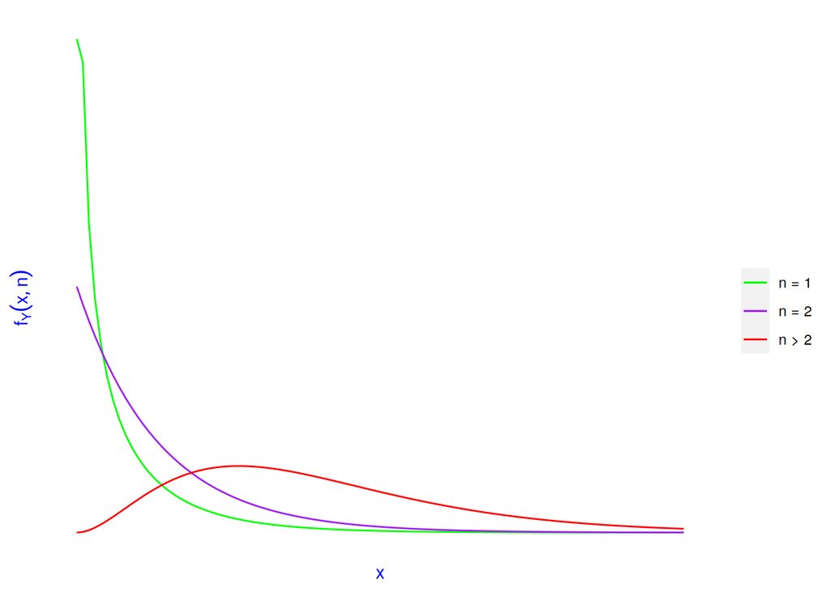

2. $Y$ имеет характеристическую функцию

$$\psi_{Y}(\lambda) = (1 - 2\lambda
i)^{\frac{n}{2}}$$

3. $Y \sim \chi^{2}(n), M[Y] = n, D[Y] = 2n$
4. Пусть *н / з* $Y_{1} \sim \chi^{2}(n_{1}), \dots, Y_{k} \sim \chi^{2}(n_{k})$. Тогда

$$\sum\limits_{k = 1}^{n} Y_{i} \sim
\chi^{2}(\sum\limits_{k = 1}^{n} n_{i})$$

5. $$\frac{Y - n}{\sqrt{2n}}
   \overset{d}{\longrightarrow} N(0; 1)$$
6. Пусть $Z_{n}$ *порожденная распределением* $N(m_{X}, \sigma_{X}^{2})$. Тогда если

$\hat{d}_{X} = \frac{1}{n} \sum\limits_{k = 1}^{n}(X_{k} - \overline{X}_{n})^{2}$,

то $\frac{n \hat{d}_{X}}{\sigma_{X}^{2}} \sim \chi^{2}(n - 1)$.

*(Доказательство приведено далее в теореме Фишера)*

## Определение 2

Пусть $X_{0}, X_{1}, \dots, X_{n} \sim N(0; 1)$ — *независимые* с.в.. Тогда с.в.

$$Y = \frac{X_{0}}{\sqrt{\frac{1}{n}
\sum\limits_{k = 1}^{n} X_{k}^{2}}} \sim t(n)$$

имеем *распределение Стьюдента* с $n$ степенями свободы.

## Свойства распределения $t(n)$

1. $Y$ имеет плотность вероятности

$$f_{x; n} = \frac{\Gamma(\frac{n +
1}{2})}{\sqrt{\pi n} \Gamma(\frac{n}{2})} (1 + \frac{x^{2}}{n})^
{- \frac{n + 1}{2}}$$

[figure not shown]

2. $Y \sim t(n), M[Y] = 0, n \geqslant 2$

$$D[Y] = \frac{n}{n - 2}, n >
2$$

3. $t(1) = C$ — *распределение Коши*
4. $Y \sim t(n), Y \overset{d}{\longrightarrow} N(0; 1)$
5. Пусть $Z_{n}$ порождена распределением $N(m_{X}; \sigma_{X}^{2})$. Тогда

$$\frac{\overline{X}_{n} -
m_{X}}{\sqrt{\hat{d}_{X}}} \cdot \sqrt{n - 1} \sim t(n - 1)$$

*(Доказательство приведено далее в теореме Фишера)*

## Определение 3

Пусть $X \sim \chi^{2}(n), Y \sim \chi^{2}(m)$ — *независимые* с.в. Тогда с.в. $V = \frac{X m}{Y n} \sim F(n; m)$ имеет *Распределение Фишера* с $n$ и $m$ степенями свободы.

## Свойства распределения $F(n; m)$

1. $V$ имеет плотность вероятности

$$f_{V}(x, n, m) =
\begin{cases}
\frac{\Gamma(\frac{n + m}{2})}{\Gamma(\frac{n}{2}) \cdot
\Gamma(\frac{m}{2})} n^{\frac{n}{2}}
m^{\frac{n}{2}} \frac{x^{\frac{n}{2} - 1}}{(m + nx)^{\frac{n + m}{2}}},
& x > 0 \\
0, & x \leqslant 0 \\
\end{cases}$$

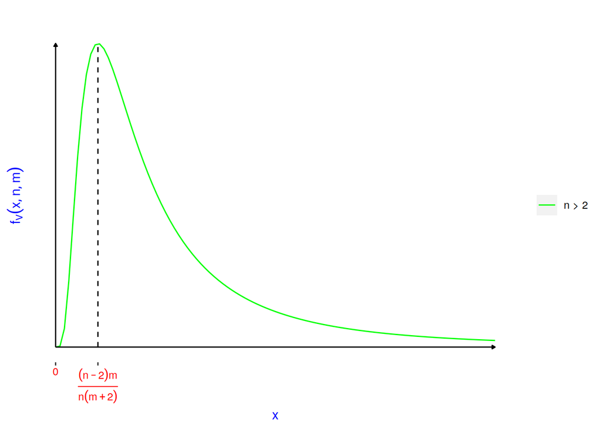

2. $V \sim F(n; m), M[V] = \frac{m}{m - 2}, m > 2$,

$$D[V] = \frac{2m^{2}(m + n - 2)}{n(m -
2)^{2}(m - 4)}, m > 4$$

3. Пусть $Z_{n} = (X_{1}, \dots, X_{n})^{T}$ и $W_{m} = (Y_{1}, \dots, Y_{m})^{T}$ — *однородные* выборки, порожденные распределениями $N(m_{X}; \sigma^{2})$ и $N(m_{Y}; \sigma^{2})$.

Тогда если $Z_{n}$ и $W_{n}$ **независимы**,

$$V = \frac{\frac{1}{n - 1} \sum\limits_{k
= 1}{n}(X_{k} - \overline{X}_{n})^{2}}
{\frac{1}{m - 1} \sum\limits_{k = 1}{n}(Y_{k} - \overline{Y}_{m})^{2}}
\sim F(n - 1; m - 1)$$

**(Данный факт следует из свойства** 6 **распределения $\chi^{2}(n)$)**

## Определение 4

*Параметром $\theta \in \mathbb{R}^{n}$ распределения* с.в. $X$ называется любая числовая характеристика, входящая в $F_{x}(x, \theta)$ явно.

## Определение 5

*Точечной оценкой* неизвестного параметра $\theta$ называется произвольная статистика $\hat{\theta}(Z_{n})$.

## Замечание

Оценка $\hat{\theta}(Z_{n})$ является с.в.

## Определение 6

*Оценка* $\hat{\theta}(Z_{n})$ называется *несмещенной*, если
$$M[\hat{\theta}] = \theta$$

## Определение 7

Оценка $\hat{\theta}(Z_{n})$ называется *состоятельной*, если
$$\hat{\theta} \overset{P}{\longrightarrow}
\theta$$

## Определение 8

Оценка $\hat{\theta}(Z_{n})$ называется *сильно состоятельной*, если
$$\hat{\theta}
\overset{\text{п.н.}}{\longrightarrow} \theta$$

## Определение 9

Оценка $\hat{\theta}(Z_{n})$ называется *с.к. состоятельной*, если
$$\hat{\theta}
\overset{\text{с.к.}}{\longrightarrow} \theta$$

## Замечание

1. Из свойств $\overline{X}_{n}$ следует, что $\overline{X}_{n}$ — **несмещенная** и **сильносостоятельная** оценка $m_{X}$.
2. Из свойств $\hat{d}_{X}$ следует, что $\hat{d}_{X}$ — **смещенная** и **сильносостоятельная** оценка $m_{X}$.

## Определение 10

*Несмещенная* оценка $\hat{\theta}^{*}(Z_{n})$ называется **эффективной**, если $\forall \hat{\theta}(Z_{n})$ — *несмещенной* оценки верно, что

$$D[\hat{\theta}^{*}(Z_{n})] \leqslant
D[\hat{\theta}(Z_{n})]$$

## Пример

Пусть $M[\overline{X}] < \infty$. Тогда $\overline{X}$ — *сильно состоятельная* оценка $m_{X}$. Если $D[\overline{X}] < \infty$, то $\overline{X}$ — *с.к.-состоятельная* оценка $m_{X}$

*(Доказательство следует из ЗБЧ)*

## Теорема 1

Пусть $\hat{\theta}_{1}, \hat{\theta}_{2}$, — *с.к.-оптимальные* оценки параметра $\theta$. Тогда

$$\hat{\theta}_{1} =
\hat{\theta}_{2}$$

### Доказательство

Т.к. $\hat{\theta}_{1}$ и $\hat{\theta}_{2}$ **оптимальны**, то $D[\hat{\theta}_{1}] = D[\hat{\theta}_{2}] = d$.

Пусть $\hat{\theta}_{3} = \frac{1}{2} (\hat{\theta}_{1} + \hat{\theta}_{2})$. Тогда

$D[\hat{\theta}_{3}] = \frac{1}{4} D[\hat{\theta}_{1} + \hat{\theta}_{2}] = \frac{1}{4} (D[\hat{\theta}_{1}] + [D\hat{\theta}_{2}] + 2\mathrm{cov}(\hat{\theta}_{1}, \hat{\theta}_{2})) = \frac{1}{2}(d + \mathrm{cov}(\hat{\theta}_{1}, \hat{\theta}_{2})) \leqslant \frac{1}{2}(d + |\mathrm{cov}(\hat{\theta}_{1}, \hat{\theta}_{2})|) \leqslant \frac{1}{2}(d + \sqrt{D[\hat{\theta}_{1}] \cdot D[\hat{\theta}_{2}]}) = d$

Тогда *в силу оптимальности* $\hat{\theta}_{1}$ и $\hat{\theta}_{2}$

$$D[\hat{\theta}_{3}] = d$$

$d = D[\hat{\theta}_{3}] = \frac{1}{2}(d + \mathrm{cov}(\hat{\theta}_{1}, \hat{\theta}_{2}))$, $\mathrm{cov}(\hat{\theta}_{1}, \hat{\theta}_{2}) = d = \sqrt{D[\hat{\theta}_{1}] \cdot D[\hat{\theta}_{2}]}$,

т.е. в *неравенстве Коши-Буняковского* достигается *равенство*. Следовательно,

$$\hat{\theta}_{1} = \alpha
\hat{\theta}_{2} + \beta, \alpha > 0$$

$$\begin{cases}
M[\hat{\theta}_{1}] = \alpha M[\hat{\theta}_{2}] + \beta \\
D[\hat{\theta}_{1}] = \alpha^{2} D[\hat{\theta}_{2}] \\
\end{cases} \implies
\begin{cases}
\theta = \alpha \theta + \beta \\
d = \alpha^{2} d \\
\end{cases} \implies
\begin{cases}
\beta = 0 \\
\alpha = 1 \\
\end{cases}$$

Окончательно, $\hat{\theta}_{1} = \hat{\theta}_{2}$. $\blacksquare$

# Эффективные оценки

Обозначим через $f(x; \theta)$ плотность вероятности с.в. $X$, порождающей **выборку** в *абсолютно непрерывном случае* или **функцию** в *дискретном случае*. В силу *критерия независимости* функция

$$L(z_{n}; \theta) = \prod\limits_{k =
1}^{n} f(x_{k}; \theta)$$

является *плотностью вероятности* с.в. $Z_{n}$.

## Определение 1

$L(z_{n}; \theta)$ при фиксированном $z_{n} \in S$ и переменной $\theta$ называется *функцией правдоподобия*.

## Замечание

Далее будем полагать, что $\theta \in \mathbb{R}^{1}$.

## Определение 2

Распределение с.в. $X$ называется *регулярным*, если

1. $\sqrt{f(x;\theta)}$ — **дифференцируема** по $\theta$ *почти для всех* $x$.
2. $i(\theta) = \int\limits_{- \infty}^{+ \infty}(\frac{\partial \ln f(x; \theta)}{\partial \theta})^{2} f(x; \theta) dx$ **конечна**, **непрерывна** по $\theta$ и **положительна**.

## Замечание

Далее будем предполагать, что выборка $Z_{n}$ порождена *регулярным распределением*.

## Определение 3

Случайная величина

$$U(Z_{n}; \theta) = \frac{\partial \ln
L(Z_{n}; \theta)}{\partial \theta} =
\sum\limits_{k = 1}^{n} \frac{\partial \ln f(x; \theta)}{\partial
\theta}$$

называется *вкладом выборки $Z_{n}$*

## Лемма 1

Пусть распределение *регулярное*. Тогда

$$M[U(Z_{n}; \theta)] = 0$$

### Доказательство

В силу *условия нормировки*

$$\int\limits_{\mathbb{R}^{n}} L(z_{n};
\theta)d_{X_{1}}, \dots, d_{X_{n}} = 1$$

С учетом *условий регулярности*

$0 = \frac{\partial}{\partial \theta} \int\limits_{\mathbb{R}^{n}} L(z_{n}; \theta)d_{X_{1}}, \dots, d_{X_{n}} = \int\limits_{\mathbb{R}^{n}} \frac{\partial L(z_{n}; \theta)}{\partial \theta}d_{X_{1}}, \dots, d_{X_{n}} = \int\limits_{\mathbb{R}^{n}} \frac{\partial \ln L(z_{n}; \theta)}{\partial \theta} L(z_{n}; \theta)d_{X_{1}}, \dots, d_{X_{n}} = M[U(Z_{n}; \theta)]$. $\blacksquare$

## Определение 4

*Информацией Фишера* о параметре $\theta$, *содержащейся в выборке $Z_{n}$*, называют

$$I_{n}(\theta) = D[U(Z_{n}; \theta)]
\overset{\text{регул.}}{=} M[U^{2}(Z_{n}; \theta)]$$

$i(\theta) = M[(\frac{\partial \ln f(x; \theta)}{\partial \theta})^{2}]$ называется *количеством информации Фишера, содержащимся в одном наблюдении*.

## Замечание

Из определения $U(Z_{n}; \theta)$ и *независимости* элементов выборки следует, что $I_{n}(\theta) = n \cdot i(\theta)$, т.е. количество информации **вырастает пропорционально объему выборки**.

## Лемма 2

Пусть $f(x; \theta)$ *дважды непрерывно дифференцируема* по $\theta$. Тогда

$$i(\theta) = - M[\frac{\partial^{2} \ln
f(X_{1}; \theta)}{\partial \theta^{2}}]$$

### Доказательство

$U(X_{1}; \theta) = \frac{\partial \ln f(X_{1}; \theta)}{\partial \theta}$. С учетом Леммы 1

$0 = \frac{\partial}{\partial \theta} M[U(X_{1}; \theta)] = \frac{\partial}{\partial \theta} \int\limits_{- \infty}^{+ \infty} \frac{\partial \ln f(x; \theta)}{\partial \theta} f(x; \theta) dx = \int\limits_{- \infty}^{+ \infty} \frac{\partial^{2} \ln f(x; \theta)}{\partial \theta^{2}} f(x; \theta)dx + \int\limits_{- \infty}^{+ \infty} \frac{\partial \ln f(x; \theta)}{\partial \theta} \cdot \frac{\partial f(x; \theta)}{\partial \theta} dx = \int\limits_{- \infty}^{+ \infty} \frac{\partial^{2} \ln f(x; \theta)}{\partial \theta^{2}} f(x; \theta)dx + \int\limits_{- \infty}^{+ \infty} (\frac{\partial \ln f(x; \theta)}{\partial \theta})^{2} f(x; \theta)dx = M[\frac{\partial^{2} \ln f(x; \theta)}{\partial \theta^{2}}] + i(\theta)$. $\blacksquare$

## Пример 1

Пусть $X \sim N(\theta; \sigma^{2})$.

$$f(x; \theta) = \frac{1}{\sqrt{2 \pi
\sigma^{2}}} \exp\{- \frac{(x - \theta)^{2}}{2
\sigma^{2}}\}$$

$$U(X_{1}; \theta) =
\frac{\partial}{\partial \theta}(- \frac{1}{2} \ln(2\pi \sigma^{2}) -
\frac{(x - \theta)^{2}}{2 \sigma^{2}}) = \frac{X_{T}
\theta}{\sigma^{2}}$$

$$\frac{\partial^{2} \ln f(x;
\theta)}{\partial \theta^{2}} = - \frac{1}{\sigma^{2}}$$

С учетом Леммы 2

$$i(\theta) = -M[- \frac{1}{\sigma^{2}}] =
\frac{1}{\sigma^{2}}$$

## Пример 2

Рассмотрим нерегулярную модель.

$$X \sim R(0; \theta)$$

Здесь из множества $\int\limits_{0}^{\theta} \frac{1}{\theta} dx = 1$ не следует, что $\int\limits_{0}^{\theta} \frac{\partial}{\partial \theta}(\frac{1}{\theta}) dx = 0$, т.к. при диффференцировании по $\theta$ появляется еще одно слагаемое:

$\frac{\partial}{\partial \theta} \int\limits_{0}^{\theta}\frac{1}{\theta} dx = \frac{1}{\theta} + \int\limits_{0}^{\theta} \frac{\partial}{\partial \theta}(\frac{1}{\theta})dx$

## Теорема 1 (Неравенство Рао-Крамера)

Пусть распределение $F(x; \theta)$, порождающее выборку $Z_{n}$ *регулярно*. Тогда для любой несмещенной оценки $\hat{\theta}$ верно неравенство:

$$D[\hat{\theta}(Z_{n})] \geqslant
\frac{1}{I_{n}(\theta)} = \frac{1}{n i(\theta)}$$

При этом равенство достигается лишь в том случае, если

$\hat{\theta}(Z_{n}) - \theta = a(\theta) \cdot U(Z_{n}; \theta)$, где

$a(\theta)$ — некоторая функция от $\theta$

### Доказательство

В силу *несмещенности* $\hat{\theta}$

$$M[\hat{\theta}] =
\int\limits_{\mathbb{R}^{n}} (z_{n})L(z_{n}; \theta)dx_{1}, \dots,
dx_{n} = \theta$$

В силу *регулярности* и Леммы 1

$1 = \frac{\partial}{\partial \theta} (\theta) = \frac{\partial}{\partial \theta} M[\hat{\theta}] = \int\limits_{\mathbb{R}^{n}} \hat{\theta}(z_{n}) \frac{\partial L(z_{n}; \theta)}{\partial \theta} dx_{1}, \dots, dx_{n} = \int\limits_{\mathbb{R}^{n}} \hat{\theta}(z_{n}) \frac{\partial \ln L(z_{n}; \theta)}{\partial \theta} \cdot L(z_{n}; \theta) dx_{1}, \dots, dx_{n} = M[\hat{\theta} U(Z_{n}; \theta)] = M[(\hat{\theta} - 0)(U(Z_{n}; \theta) - \theta)] + \theta \cdot M[U(Z_{n}; \theta)] = \mathrm{cov}(\hat{\theta}, U(Z_{n}; \theta))$

Откуда с учетом *неравенства Коши-Буняковского*

$$1^{2} \leqslant D[\hat{\theta}] \cdot
D[U(Z_{n}; \theta)] = D[\hat{\theta}] \cdot I_{n}(\theta)$$

Причем *равенство достигается* в том и только том случае, когда $\hat{\theta} = a(\theta)U(Z_{n}; \theta) + b(\theta)$

Но с учетом Леммы 1 $b(\theta) = 0$.

## Определение 5

Оценка $\hat{\theta}^{*}(Z_{n})$, *для которой достигается равенство в неравенстве Рао-Крамера* называется *эффективной*

## Замечание

В силу Теоремы 1 эффективная оценка является *оптимальной*. А с учетом Теоремы 7.1 эффективная оценка **единственна**

## Пример 3

Пусть $X \sim N(\theta; \sigma^{2})$

$U(Z_{n}; \theta) = \sum\limits_{k = 1}^{n} \frac{\partial \ln f(X_{k}; \theta)}{\partial \theta} = \sum\limits_{k = 1}^{n} \frac{X_{k} - \theta}{\sigma^{2}} = \frac{n}{\sigma^{2}} (\overline{X}_{n} - \theta)$

Т.о. $a(\theta) = \frac{\sigma^{2}}{n}$. Тогда $a(\theta) U(Z_{n}; \theta) = \overline{X}_{n} - \theta$, откуда следует, что $\overline{X}_{n}$ — *эффективная оценка*.

# Методы построения точеченых оценок

## Определение 1

*Оценкой максимального правдоподобия* $\theta$ называют

$$\hat{\theta} = \underset{\theta}{argmax}
L(Z_{n};\theta)$$

## Замечание

1. В силу *монотонности* функции $\ln x$ справедливо представление:

$$\hat{\theta} = \underset{\theta}{argmax}
L(Z_{n}; \theta) = \underset{\theta}{argmax}
\ln L(Z_{n}; \theta)$$

2. Если $L(Z_{n}; \theta)$ — **гладкая** и **максимум** по $\theta$ достигается **внутри множества** возможных значений $\theta$, то $\theta$ можно вычислить из *уравнения правдоподобия*

$$U(Z_{n}; \theta) = \frac{\partial \ln
L(z_{n}; \theta)}{\partial \theta} = 0$$

3. Из Теоремы 8.1 следует, что $\hat{\theta}$ **будет также эффективной оценкой**.

## Пример 1

Рассмотрим случайную величину $X \sim N(m; \sigma^{2})$ с неизвестными $m$ и $\sigma^{2}$:

$$\theta = (m;
\sigma^{2})^{T}$$

$$L(Z_{n}; \theta) = \prod\limits_{k =
1}^{n} \frac{1}{\sqrt{2\pi \theta_{2}}}
e^{- \frac{(X_{k} - \theta_{1})^{2}}{2 \theta_{2}}}$$

$$\ln L(Z_{k}; \theta) = \sum\limits_{k =
1}{n}(- \frac{1}{2} \ln(2\pi) - \frac{1}{2} \ln \theta_{2} -
\frac{(X_{k} - \theta_{1})^{2}}{2 \theta_{2}})$$

$\begin{cases} \frac{\partial \ln L(Z_{n}; \theta)}{\partial \theta_{1}} = \sum\limits_{k = 1}^{n} \frac{(X_{k} - \theta_{1})}{\theta_{2}} = \frac{1}{\theta_{2}}(n \overline{X}_{n} - n \theta_{1}) = 0 \\ \frac{\partial \ln L(Z_{n}; \theta)}{\partial \theta_{2}} = \sum\limits_{k = 1}^{n} (\frac{(X_{k} - \theta_{1})^{2}}{2 \theta_{2}^{2}} - \frac{1}{2 \theta_{2}}) = \frac{1}{2 \theta_{2}}(n \hat{d}_{X}(n) - n \theta_{2}) = 0 \\ \end{cases}$

$\begin{cases} \hat{\theta}_{1} = \overline{X}_{n} \\ \hat{\theta}_{2} = \hat{d}_{X}(n) \\ \end{cases}$

## Пример 2

Пусть $X \sim R(\theta_{1}; \theta_{2})$. В этом случае $L(Z_{n}; \theta)$ **не является** непрерывной:

$$L(Z_{n}; \theta) = \prod\limits_{k =
1}^{n} f_{X} (X_{k}; \theta) =
\begin{cases}
0, & \exists k = \overline{1, n} : X_{k} \notin [\theta_{1};
\theta_{2}] \\
\frac{1}{(\theta_{2} - \theta_{1})^{n}}, & \forall k =
\overline{1, n} : X_{k} \in [\theta_{1};
\theta_{2}] \\
\end{cases}$$

Тогда оценка максимального правдоподобия **не может быть вычислена из уравнений правдоподобия**. Хотя $\hat{\theta}$ существует:

$$L(Z_{n}; \theta) =
\begin{cases}
0, & \min_{k = \overline{1, n}} X_{k} < \theta_{1} || \max_{k
= \overline{1, n}} X_{k} > \theta_{2} \\
\frac{1}{(\theta_{2} - \theta_{1})^{n}}, & \theta_{1} \leqslant
\min_{k = \overline{1, n}} X_{k}
\leqslant \max_{k = \overline{1, n}} X_{k} \leqslant \theta_{2} \\
\end{cases}$$

Откуда $L(Z_{n}; \theta)$ *возрастает* по $\theta_{1}$ и *убывает* по $\theta_{2}$

Тогда $\hat{\theta}_{1} = \min_{k = \overline{1, n}} X_{k} = X^{(1)}, \hat{\theta}_{1} = \max_{k = \overline{1, n}} X_{k} = X^{(n)}$

## Замечание

Для МП-оценок выполняется **принцип инвариантности**:

Пусть $g(\theta)$ — *биективное* отображение.

Тогда МП-оценка $\hat{g}(Z_{n}) = g(\hat{\theta}(Z_{n}))$.

Действительно,

$\sup\limits_{\theta} L(Z_{n}; \theta) = \sup\limits_{g} L(Z_{n}; g^{-1}(g))$

Тогда $g^{-1}(\hat{g}) = \hat{\theta}$, т.е. $\hat{g} = g(\hat{\theta})$

## Пример 3

Пусть $X \sim N(\theta_{1}; \theta_{2})$. Требуется оценить $F_{X}(x_{0}) = \frac{1}{2} + \Phi_{0}(\frac{x_{0} - \theta_{1}}{\theta_{2}})$. Рассмотрим *биективное отображение*

$$g(\theta_{1}; \theta_{2}) =
\begin{pmatrix}
\frac{1}{2} + \Phi_{0}(\frac{x_{0} - \theta_{1}}{\theta_{2}}) \\
\theta_{2} \\
\end{pmatrix}$$

Тогда

$$\hat{g}(Z_{n}) =
\begin{pmatrix}
\frac{1}{2} + \Phi_{0}(\frac{x_{0} -
\overline{X}_{n}}{\sqrt{\hat{d}_{X}(n)}}) \\
\sqrt{\hat{d}_{X}(n)} \\
\end{pmatrix}$$

$X_{0} \in \mathbb{R}$

## Замечание

Для решения уравнений правдоподобия часто используются *численные методы*

## Теорема 1

Пусть распределение с.в. $X$, порождающей выборку $Z_{n}$, *регулярно*.

Функция правдоподобия $L(z_{n}; \theta)$ *имеет единственный достижимый максимум* по $\theta \forall z_{n} \in S, n \in \mathbb{N}$. Тогда

1. МП-оценка $\hat{\theta}$ *состоятельна*;
2. Если $|\frac{\partial^{k} f(x; \theta)}{\partial \theta^{k}}| \leqslant g_{k}(x), \forall \theta$, где

$\int\limits_{\mathbb{R}} g_{1}(x)dx < \infty, \int\limits_{\mathbb{R}} g_{2}(x)dx < \infty, \int\limits_{\mathbb{R}} g_{3}(x)f(x; \theta)dx \leqslant C \leqslant \infty$, а функция $i(\theta) = \int\limits_{\mathbb{R}} (\frac{\partial \ln f(x; \theta)}{\partial \theta})^{2} f(x; \theta)dx$ *конечна* и *положительна* $\forall \theta$, то

2.1 $M[\hat{\theta}] \to \theta$ *(асимптотически несмещенность)*

2.2 $\hat{\theta}$ *сильно состоятельна*;

2.3 $\sqrt{n i (\theta)}(\hat{\theta} - \theta) \overset{d}{\longrightarrow} N(0; 1)$

*Асимптотическая нормальная*

## Определение 2

Пусть $\theta = (\theta_{1}, \dots, \theta_{r})^{T}$, а для распределения $F_{X}(x; \theta)$, порождающего выборку $Z_{n}, M[X^{r}] < \infty$

Тогда

$$\begin{cases}
\nu_{1}(\theta) = & \hat{\nu}_{1}(n) \\
\vdots & \vdots \\
\nu_{r}(\theta) = & \hat{\nu}_{r}(n) \\
\end{cases}$$

называется *системой метода моментов*.

## Определение 3

Решение системы метода моментов

$$\hat{\theta}_{i} =
\varphi_{i}(\hat{\nu}_{1}(n), \dots, \hat{\nu}_{r}(n)), i = \overline{1,
r}$$

называется *оценкой метода моментов*.

## Теорема 2

Пусть функции $\varphi_{1}, \dots, \varphi_{r}$, определяющие оценку метода моментов *непрерывные* и *биективные*. Тогда оценка метода моментов *состоятельна*.

### Доказательство

Доказательство следует из **состоятельности** статистик $\hat{\nu}_{i}(n)$.

## Пример 1

$X \sim N(\theta_{1}; \theta_{2})$. Тогда $\hat{\theta}_{1} = \overline{X}_{n}, \hat{\theta}_{2} = \hat{d}_{X}(n)$

## Пример 2

$X \sim R(\theta_{1}; \theta_{2})$. Тогда

$$\begin{cases}
\overline{X}_{n} = \frac{\theta_{1} + \theta_{2}}{2} \\
\hat{d}_{X}(n) = \frac{(\theta_{2} - \theta_{1})^{2}}{12} \\
\end{cases}
\begin{cases}
\theta_{1} + \theta_{2} = 2 \overline{X}_{n} \\
\theta_{2} - \theta_{1} = 2 \sqrt{\hat{d}_{X}(n)}\sqrt{3} \\
\end{cases}
\begin{cases}
\theta_{1} = \overline{X}_{n} - \sqrt{3 \hat{d}_{X}(n)} \\
\theta_{2} = \overline{X}_{n} + \sqrt{3 \hat{d}_{X}(n)} \\
\end{cases}$$

## Замечание

Метод моментов **трудноприменим**, если *теоретические моменты не удается вычислить явно*.

# Интервальные оценки

## Определение 1

Пусть выполнено условие:

$$P(\hat{\theta}_{1}(Z_{n}) \leqslant
\theta \leqslant \hat{\theta}_{2}(Z_{n})) = 1 - \alpha$$

для некоторого распределения параметром $F_{x}(x; \theta)$. Тогда интервал $[\hat{\theta}_{1}(Z_{n}); \hat{\theta}_{2}(Z_{n})]$ — называется *доверительным интервалом* или *интервальной оценкой* параметра $\theta$ уровня надежности $1 - \alpha$.

## Определение 2

Доверительный интервал называется *центральным*, если верно условие:

$$P(\theta \leqslant
\hat{\theta}_{1}(Z_{n})) = P(\theta \geqslant \hat{\theta}_{2}(Z_{n})) =
\frac{\alpha}{2}$$

## Определение 3

Доверительный интервал называется *правосторонним* или *левосторонним*, если выполнено условие:

$P(\theta \geqslant \hat{\theta}_{2}(Z_{n})) = \alpha$ или $P(\theta \leqslant \hat{\theta}_{1}(Z_{n})) = \alpha$

## Замечание

1. Можно визуализировать интервальную оценку следующим образом:

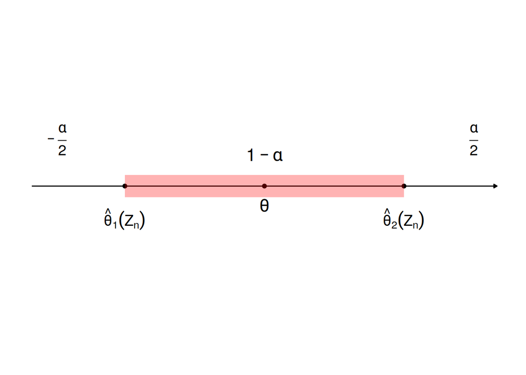

2. Интервальную оценку можно рассматривать в качестве оценки погрешности точеченой оценки $\hat{\theta}(Z_{n})$, если строить доверительный интервал в форме:

$$[\hat{\theta}(Z_{n}) - \varepsilon_{1};
\hat{\theta}(Z_{n}) + \varepsilon_{2}]$$

где $\varepsilon_{1}, \varepsilon_{2} > 0$.

## Определение 4

Статистика $G(Z_{n}; \theta)$ называется *центральной*, если $G$ *непрерывна* и *строго монотонна* по $\theta, \forall z_{n} \in S$, а ее распределение **не зависит** от $\theta$.

Если распределение $F_{G}(Z_{n}; \theta)$ известно, то можно подобрать числа $g_{1}, g_{2}$ такие, что $P(g_{1} \leqslant G(Z_{n}; \theta) \leqslant g_{2}) = 1 - \alpha$.

Например, для центрального доверительного интервала $g_{1} = G_{\frac{\alpha}{2}}, g_{2} = G_{1 - \frac{\alpha}{2}}$ — квантили уровней $\frac{\alpha}{2}$ и $1 - \frac{\alpha}{2}$.

Если $G(Z_{n}; \theta)$ *монотонно возрастает* по $\theta$, то можно перейти к эквивалентному неравенству:

$$P(G^{-1}(Z_{n}; g_{1}) \leqslant \theta
\leqslant G^{-1}(Z_{n}; g_{2}) = 1 - \alpha$$

Тогда границы интервальной оценки имеют вид:

$$\hat{\theta}_{1}(Z_{n}) = G^{-1}(Z_{n};
g_{1}), \hat{\theta}_{2}(Z_{n}) = G^{-1}(Z_{n}; g_{2})$$

## Замечание

Построение центральных статистик **довольно сложно**. В связи с чем зачастую используют **асимптотические распределения**, которые в силу ЦПТ тесно связаны с нормальным распределением.

## Определение 5

Матрица $C \in \mathbb{R}^{n \times n}$ называется *ортогональной*, если $C^{T} = C^{-1}$.

## Лемма 1

Пусть $C \in \mathbb{R}^{n \times n}$ — *ортогональная матрица*, $C_{1j} = \frac{1}{\sqrt{n}}, j = \overline {1, n}$. Тогда

1. $\sum\limits_{k = 1}^{n} C_{jk} \cdot C_{ik} = 0, j \neq i; i,j = \overline{1, n}$
2. $\sum\limits_{k = 1}^{n} C_{ik}^{2} = 1, i = \overline{1, n}$
3. Если $y = Cx$, то $\lVert y \rVert = \lVert x \rVert$
4. $\sum\limits_{k = 1}^{n} C_{ik} = 0, i= \overline{2, n}$

### Доказательство

Пункты *1* и *2* следуют из тождества

$$C^{T} \cdot C = I$$

3. $\lVert y \rVert^{2} = (y, y) = (Cx, Cx) = (x, C^{T}Cx) = (x, x) = \lVert x \rVert^{2}$
4. Рассмотрим свойство *1* для $i = 1$. Тогда

$$0 = \sum\limits_{k = 1}^{n} C_{1k} \cdot
C_{ik} = \sum\limits_{k = 1}^{n} \frac{1}{\sqrt{n}} C_{ik} =
\frac{1}{\sqrt{n}} \sum\limits_{k = 1}^{n} C_{ik}$$

$\blacksquare$

## Теорема 1 (ФИШЕРА)

Пусть $Z_{n}$ — *однородная* выборка, порожденная распределением $N(m_{X}; \sigma_{X}^{2})$. Тогда

1. $\frac{\overline{X}_{n} - m_{X}}{\sigma_{X}} \sqrt{n} \sim N(0; 1)$
2. $\frac{n \hat{d}_{X}(n)}{\sigma_{X}^{2}} \sim \chi(n - 1)$
3. $\frac{\overline{X}_{n} - m_{X}}{\sqrt{\hat{d}_{X}(n)}} \sqrt{n - 1} \sim t(n - 1)$
4. $\overline{X}_{n}$ и $\hat{d}_{X}(n)$ **независимы**

### Доказательство

.1) $\frac{\overline{X}_{n} - m_{X}}{\sigma_{X}} \sqrt{n} = \sum\limits_{k = 1}^{n} \frac{1}{\sigma_{X} \sqrt{n}} X_{k} - \frac{m_{X}\sqrt{n}}{\sigma_{X}} = (\frac{1}{\sigma_{X} \sqrt{n}} + \frac{1}{\sigma_{X} \sqrt{n}} + \dots + \frac{1}{\sigma_{X} \sqrt{n}}) \cdot Z_{n} - \frac{m_{X}\sqrt{n}}{\sigma_{X}}$.

Т.к. $Z_{n} \sim N( \begin{pmatrix} m_{X} \\ \vdots \\ m_{X} \\ \end{pmatrix}; \sigma_{X}^{2} I)$, то в силу Леммы 1.3

$\frac{\overline{X}_{n} - m_{X}}{\sigma_{X}} \sqrt{n} \sim N(m; \sigma^{2})$, где $m = (\frac{1}{\sigma_{X} \sqrt{n}} \dots \frac{1}{\sigma_{X} \sqrt{n}}) \begin{pmatrix} m_{X} \\ \vdots \\ m_{X} \\ \end{pmatrix} - \frac{m_{X}\sqrt{n}}{\sigma_{X}} = 0$

$$\sigma^{2} = (\frac{1}{\sigma_{X}
\sqrt{n}} \dots \frac{1}{\sigma_{X} \sqrt{n}}) \sigma^{2} I \cdot
\begin{pmatrix}
\frac{1}{\sigma_{X} \sqrt{n}} \\
\vdots \\
\frac{1}{\sigma_{X} \sqrt{n}} \\
\end{pmatrix} = 1$$

.2) Построим матрицу $C \in \mathbb{R}^{n \times n}$ так, чтобы $C_{1j} = \frac{1}{\sqrt{n}}, j = \overline{1,n}$; остальные строки выберем так, чтобы векторы $\begin{pmatrix} C_{11} \\ \vdots \\ C_{1n} \\ \end{pmatrix}, \begin{pmatrix} C_{21} \\ \vdots \\ C_{2n} \\ \end{pmatrix}, \dots, \begin{pmatrix} C_{n1} \\ \vdots \\ C_{nn} \\ \end{pmatrix} \in \mathbb{R}^{n}$

образовывали *ортонормированный* базис, что возможно, т.к. вектор $\begin{pmatrix} C_{11} \\ \vdots \\ C_{1n} \\ \end{pmatrix} = \begin{pmatrix} \frac{1}{\sqrt{n}} \\ \vdots \\ \frac{1}{\sqrt{n}} \\ \end{pmatrix}$ всегда можно дополнить до *ортонормированного* базиса.

Тогда $C$ удовлетворяет условиям Леммы 1.

Рассмотрим $Y = \frac{1}{\sigma_{X}} C Z_{n}$. Тогда $Y \sim N(m_{Y}; K_{Y})$, где в силу Леммы 1.3 и Леммы 1, п.4:

$$m_{Y} = \frac{1}{\sigma_{X}}
C(\sigma_{X}^{2} I) \frac{1}{\sigma_{X}} C^{T} = CIC^{T} = CC^{T} =
I$$

Т.о. $Y_{1}, \dots, Y_{n}$ — **некоррелированные** нормальные с.в.

Тогда в силу Леммы 1.4 $Y_{1}, \dots, Y_{n}$ *независимы*

$\frac{n \hat{d}_{X}(n)}{\sigma_{X}^{2}} = \frac{1}{\sigma_{X}^{2}} \sum\limits_{k = 1}^{n}(X_{k} - \overline{X}_{n})^{2} = \frac{1}{\sigma_{X}^{2}} \sum\limits_{k = 1}^{n}(X_{k}^{2} - 2 X_{k}\overline{X}_{n} + \overline{X}_{n}^{2}) = \frac{1}{\sigma_{X}^{2}} (\sum\limits_{k = 1}^{n} X_{k}^{2} - 2n \overline{X}_{n}(\frac{1}{n} \sum\limits_{k = 1}^{n} X_{k}) + n \overline{X}_{n}^{2}) = \frac{1}{\sigma_{X}^{2}} \sum\limits_{k = 1}^{n} X_{k}^{2} - \frac{n}{\sigma_{X}^{2}} \overline{X}_{n}^{2} \overset{*}{=}$

$Y_{1} = \frac{1}{\sigma_{X} \sqrt{n}}(X_{1} + \dots + X_{n}) = \frac{\sqrt{n}}{\sigma_{X}} \overline{X}_{n}$. Тогда с учетом Леммы 1

$\overset{*}{=} \frac{1}{\sigma_{X}^{2}} \lVert Z_{n} \rVert^{2} - Y_{1}^{2} = \frac{1}{\sigma_{X}^{2}} \lVert C Z_{n} \rVert^{2} - Y_{1}^{2} = \lVert \frac{1}{\sigma_{X}}Z_{n} \rVert^{2} - Y_{1}^{2} = \lVert Y \rVert^{2} - Y_{1}^{2} = \sum\limits_{k = 1}^{n} Y_{k}^{2} - Y_{1}^{2} = \sum\limits_{k = 2}^{n} Y_{k}^{2}$, где

$Y_{k} \sim N(0; 1), k = \overline{2, n}$. Тогда по определению

$$\frac{n \hat{d}_{X}(n)}{\sigma_{X}^{2}}
= \sum\limits_{k = 2}^{n} Y_{k}^{2} \sim \chi^{2}(n - 1)$$

.4) Заметим, что $\overline{X}_{n} = \frac{\sigma_{X}}{\sqrt{n}} Y_{1} = \varphi(Y_{1})$, где $Y_{1}$ и $(Y_{2}, \dots, Y_{n})^{T}$ **независимы**. Тогда **независимы** также $\varphi(Y_{1})$ и $\psi(Y_{2}, \dots, Y_{n})$, т.е. $\overline{X}_{n}$ и $\hat{d}_{X}(n)$

.3) $\frac{\overline{X}_{n} - m_{X}}{\sqrt{\hat{d}_{X}(n)}} \sqrt{n - 1} = \frac{\frac{\sigma_{X}}{\sqrt{n}} Y_{1} - m_{X}}{\sqrt{\frac{\sigma_{X}^{2}}{n} \sum\limits_{k = 2}^{n} Y_{k}^{2}}}\sqrt{n - 1} = \frac{Y_{1} - \frac{m_{X} \sqrt{n}}{\sigma_{X}}}{\sqrt{\frac{1}{n - 1} \sum\limits_{k = 2}^{n} Y_{k}^{2}}} \sim t(n - 1)$, т.к.

$Y_{1} - \frac{m_{X}\sqrt{n}}{\sigma_{X}} \sim N(0; 1)$ и $Y_{1}, (Y_{2}, \dots, Y_{n})^{T}$ **независимы**. $\blacksquare$

## Пример 3

Построить интервальную оценку $\theta$ по однородной выборке $Z_{n}$, порожденной распределением $N(\theta; \sigma_{X}^{2})$, если $\sigma_{X}^{2}$ *неизвестна*, уровня надежности $1 - \alpha$

В силу Теоремы Фишера

$$G(Z_{n}; \theta) =
\frac{\overline{X}_{n} - \theta}{\sqrt{\hat{d}_{X}(n)}} \sqrt{n - 1}
\sim (n - 1)$$

Тогда

$1 - \alpha = P(t_{\frac{\alpha}{2}}(n - 1) \leqslant \frac{\overline{X}_{n} - \theta} {sqrt{\hat{d}_{X}(n)}}\sqrt(n - 1) \leqslant t_{1 - \frac{\alpha}{2}}(n - 1)) = P(\overline{X}_{n} - \sqrt{\frac{\hat{d}_{X}(n)}{n - 1}} t_{1 - \frac{\alpha}{2}}(n - 1) \leqslant \theta \leqslant \overline{X}_{n} + \sqrt{\frac{\hat{d}_{X}(n)}{n - 1}} t_{1 - \frac{\alpha}{2}}(n - 1))$

Тогда интервальная оценка имеет вид:

$$[\overline{X}_{n} -
\sqrt{\frac{\hat{d}_{X}(n)}{n - 1}} t_{1 - \frac{\alpha}{2}}(n - 1);
\overline{X}_{n} + \sqrt{\frac{\hat{d}_{X}(n)}{n - 1}} t_{1 -
\frac{\alpha}{2}}(n - 1)]$$

Заметим, что $\overline{X}_{n}$ — *точечная оценка* $\theta$ — лежит в середине интервала. При этом длина интервала $2 \sqrt{\frac{\hat{d}_{X}(n)}{n - 1}} t_{1 - \frac{\alpha}{2}}(n - 1)$ **возрастает** по $\sigma_{X}^{2}$ и **убывает** по $\alpha$ и $n$.

## Пример 4

Пусть выборка $Z_{n}$ порождена распределением $R(0; \theta)$. Пусть

$$G(Z_{n}; \theta) =
(\frac{X^{(n)}}{\theta})^{n}$$

$F_{G}(x) = P((\frac{X^{(n)}}{\theta})^{n} \leqslant x) = P(X^{(n)} \leqslant \theta \sqrt[n]{x}) = F_{(n)}(\theta \sqrt[n]{x}) \overset{*}{=}$

в силу Следствия 6.1

$\overset{*}{=} (F_{X}(\theta \sqrt[n]{x}))^{n} = \begin{cases} 1^{n}, & \theta \sqrt[n]{x} \geqslant \theta, \\ 0^{n}, & 0 \leqslant 0, \\ -(\frac{\theta \sqrt[n]{x} - 0}{\theta - 0})^{n}, & 0 \leqslant (0; \theta) \\ \end{cases} = \begin{cases} 1, & x \geqslant 1, \\ 0, & x \leqslant 0, \\ x, & 0 < x < 1 \\ \end{cases} \implies G(Z_{n}; \theta) \sim R(0; 1)$

Тогда $G_{\frac{\alpha}{2}} = \frac{\alpha}{2}, G_{1 - \frac{\alpha}{2}} = 1 - \frac{\alpha}{2}$,

$$1 - \alpha = P(\frac{\alpha}{2}
\leqslant (\frac{X^{(n)}}{\theta})^{n} \leqslant 1 - \frac{\alpha}{2}) =
P(X^{(n)}(1 - \frac{\alpha}{2})^{- \frac{1}{2}} \leqslant \theta
\leqslant X^{(n)}(\frac{\alpha}{2})^{-
\frac{1}{n}})$$

Интервальная оценка имеет вид:

$$[X^{(n)}(1 - \frac{\alpha}{2})^{-
\frac{1}{n}}; X^{(n)}(\frac{\alpha}{2})^{- \frac{1}{n}}]$$

Заметим, что точечная МП-оценка $\hat{\theta}(Z_{n}) = X^{(n)}$ **не лежит внутри** интервала.

# Проверка статистических гипотез

## Определение 1

*Статистической гипотезой* $H$ называется любое предположение относительно закона распределения с.в. $X$, порождающей выборку $Z_{n}$.

## Определение 2

Проверяемая гипотеза $H_{0}$ называется *основной*. Конкурирующая с $H_{0}$ гипотеза $H_{1}$ называется *альтернативой*.

## Определение 3

*Статистическим критерием* или *критерием согласия* называется правило, в соответствии с которым по реализации выборки $z_{n} = Z_{n}(\omega)$ принимается или отвергается гипотеза $H_{0}$.

## Примеры

Пусть $F_{X}$ — распределение, порождающее выборку $Z_{n}$, $F$ — некоторая заданная функция распределения, $\mathbb{F}$ — некоторый заданный класс функций распределения.

Например, $F(x) = \frac{1}{2} + \Phi(x - 1), \mathbb{F}= \{F(x) = \frac{1}{2} + \Phi(\frac{x - m}{\sigma}): m \in \mathbb{R}, \sigma > 0\}$

Тогда можно рассмотреть

$H_{0}: F_{X}(x) = F(x), x \in \mathbb{R}$ или $H_{0}:F_{X} \in \mathbb{F}$

Пусть задано $k$ выборок $Z_{n_{1}}^{1}, \dots, Z_{n_{k}}^{k}$.

Требуется определить, образуют ли они единую однородную выборку.

Если $F_{i}(x)$ — функция распределения, порождающая выборку $Z_{n_{i}}^{i}$, то

$$H_{0} : F_{1}(x) = \dots =
F_{k}(x)$$

Пусть $Z_{n}^{1}, Z_{n}^{2}$ — *однородные* выборки, порождаемые с.в. $X$ и $Y$ соответственно с функциями распределения $F_{X}$ и $F_{Y}$.

Через $F_{X, Y}(x, y) = F_{X}(x) \cdot F_{Y}(y); x,y \in \mathbb{R}$

## Замечание

Для проверки гипотезы $H_{0}$ используется специальные статистики $T(Z_{n})$, характеризующие отклонение наблюдения от теоретического предположения.

## Определение 4

Обозначим через $G$ *множество всех возможных значений статистики $T$*:

$$G = \{t : t = T(z_{n}), z_{n} \in
S\}$$

## Определение 5

Построим разбиение $G$ на *доверительную область $G_{\circ\alpha}$ и критическую область $G_{| \alpha}$* так, чтобы

$$G_{\circ\alpha} \cup G_{| \alpha} =
G$$

$$G_{\circ\alpha} \cap G_{| \alpha} =
\varnothing$$

$P(T(z_{n}) \in G_{| \alpha} | H_{0}) \leqslant \alpha, P(T(Z_{n}) \in G_{\circ\alpha} | H_{0}) \geqslant 1 - \alpha$ для некоторого $\alpha \in (0; 1)$.

Если $H_{0}$ принимается в случае, когда $T(Z_{n}) \in G_{| \alpha}$, то $\alpha$ называется *уровнем значимости критерия*.

## Определение 6

*Ошибкой рода* называется событие, когда $H_{0}$ *верна*, но она *отвергается*

$T(z_{n}) \in G_{| \alpha}$, $H_{0}$ **верно**.

## Определение 7

*Ошибкой рода* называется событие, когда $H_{0}$ *неверно*, но она *принимается*

$T(z_{n}) \in G_{\circ\alpha}$, $H_{0}$ **неверно**.

## Замечание

1. Если $H_{0}$ *принимается*, то это не значит, что $H_{0}$ верно. Это значит, что наблюдения $z_{n} = Z_{n}(\omega)$ *согласуется* с гипотезой $H_{0}$.
2. Для построения доверительной и критической областей необходимо знать

$$Law(T(Z_{n}) | H_{0})$$

а также задать уровень значимости $\alpha$

3. Структура критической области $G_{| \alpha}$ определяется алтернативой $H_{1}$

## Определение 8

Пусть $\mathbb{F}$ — *множество всех распределений* $T(Z_{n})$, *удовлетворяющих альтернативе* $H_{1}$.

Тогда *функцией мощности критерия* $W: \mathbb{F}\to [0; 1]$ называется

$$W(F) = P(T(Z_{n}) \in G_{| \alpha} |
Law(T(Z_{n})) = F_)$$

Значение $W(F)$ называется *мощностью критерия при альтернативе $F$*.

## Определение 9

Критерий называется *несмещенным*, если $W(F) > \alpha, \forall F \in \mathbb{F}$.

## Замечание

1. Для построения $W(F)$ необходимо знать $Law(T(Z_{n}) | F)$, что не всегда доступно.
2. Качество критерия определяется функцией мощности: чем выше мощность, тем чаще критерий отвергает $H_{0}$, если она *неверна*.

$H_{0} : F_{X}(x) = F(x), x \in \mathbb{R}$

$H_{1} : F_{X}(x_{0}) \neq F(x_{0})$ для некоторого $x_{0} \in \mathbb{R}$

$$T(Z_{n}) = \sup\limits_{x \in
\mathbb{R}}|\hat{F}_{n}(x) - F(x)|$$

Данный критерий применяется для *непрерывных* $F(x)$.

$Law(T(Z_{n}) | H_{0})$ известно. Для *малых* $n \in \mathbb{N}$ соответствующие квантили берутся из таблиц. При больших $n \in \mathbb{N}$ используют *асимптотическую аппроксимацию*:

$$F_{\sqrt{n} T(Z_{n}) | H_{0}} (x)
\overset{n \to \infty}{\longrightarrow} K(x) =
\begin{cases}
\sum\limits_{k = - \infty}^{+ \infty} (-1)^{k} e^{-2k^{2}x^{2}},
& x > 0 \\
0, & x \leqslant 0 \\
\end{cases}$$

$K(x)$ — *функция распределения Колмогорова*

Пусть для выборки $Z_{n}$ построено разбиение $\mathbb{R}$:

$- \infty = t_{0} < t_{1} < t_{2} < \dots < t_{l} < t_{l + 1} = + \infty$, где

$t_{1} \leqslant X^{(1)}, t_{l} > X^{(n)}$.

На построенном разбиении построим гистограмму:

$$\hat{f}_{n}(x) =
\begin{cases}
0, & x \in (t_{0}, t_{1}) \cup [t_{l}; t_{l + 1}), \\
\hat{p}_{k}, & x \in [t_{k}; t_{k + 1}), k = \overline{1, l - 1}
\\
\end{cases}$$

Пусть $p_{k} = P(X \in [t_{k}; t_{k + 1}) |H_{0}) = F(t_{k + 1}) - F(t_{k}), k = \overline{0, l}$.

*Статистика критерия Пирсона* имеет вид:

$$T_{\chi^{2}}(Z_{n}) = n \cdot
\sum\limits_{k = 0}^{l} \frac{(\hat{p}_{k} - p_{k})^{2}}
{p_{k}}$$

где $\hat{p}_{0} = \hat{p}_{l} = 0$.

## Теорема 1

Пусть $p_{k} \in (0; 1), k = \overline{0, l}$.

Тогда

$$Law(T_{\chi^{2}}(Z_{n}) | H_{0})
\overset{n \to \infty}{\longrightarrow} \chi^{2}(l)$$

## Замечание

1. **Высокая точность** приближения законом $\chi^{2}(l)$ **достигается** при $l \geqslant 5$ и $n \geqslant 50$.
2. Если у $F(x; \theta_{1}, \dots, \theta_{5})$ теоретической функции распределения есть $s$ *неизвестных параметров*, то

$$Law(T_{\chi^{2}}(Z_{n}) | H_{0})
\overset{n \to \infty}{\longrightarrow} \chi^{2}(l - s)$$

Рассматривается выборка $Z_{n}$, порожденная распределением $N(m_{X}; \sigma_{X}^{2})$

Рассмотрим $H_{0}: m_{X} = m_{0}$ против

$H_{1} : m_{X} \neq m_{0}, H_{2} : m_{X} > m_{0}, H_{3} : m_{X} < m_{0}$

$$T(Z_{n}) = \frac{(\overline{X}_{n} -
m_{0})}{\sigma_{X}} \sqrt{n}, Law(T(Z_{n}) | H_{0}) = N(0;
1)$$

$$G_{1\alpha} = (- \infty;
u_{\frac{\alpha}{2}}) \cup (u_{1 -\frac{\alpha}{2}}; +
\infty)$$

$$G_{2\alpha} = (u_{1 -\alpha}; + \infty),
G_{3\alpha} = (- \infty; U_{\alpha})$$

$$T(Z_{n}) = \frac{(\overline{X}_{n} -
m_{0})}{\sqrt{\hat{d}_{X}(n)}} \sqrt{n - 1},
Law(T(Z_{n}) | H_{0}) = t(n - 1)$$

$$G_{1\alpha} = (- \infty;
t_{\frac{\alpha}{2}}(n - 1)) \cup (t_{1 -\frac{\alpha}{2}}(n - 1);+
\infty)$$

$$G_{2\alpha} = (t_{1 -\alpha}(n - 1); +
\infty), G_{3\alpha} = (- \infty; t_{\alpha}(n - 1))$$

Рассмотрим $H_{0}: \sigma_{X}^{2} = \sigma_{X}^{2}$ против

$H_{1} : \sigma_{X}^{2} \neq \sigma_{0}^{2}$

$$T(Z_{n}) = \frac{\sum\limits_{k =
1}^{n}(X_{k} - m_{X})}{\sigma_{0}^{2}},
Law(T(Z_{n}) | H_{0}) = \chi^{2}(n)$$

$$T(Z_{n}) = \frac{n
\hat{d}_{X}(n)}{\sigma_{0}^{2}},
Law(T(Z_{n}) | H_{0}) = \chi^{2}(n - 1)$$

# Метод наименьших квадратов

В рамках регрессионного анализа рассматривается задача восстановления зависимости $Y = \varphi(x)$ по набору наблюдений $Y_{1}, \dots, Y_{n}$, которые предполагаются **защищенными**.

## Определение 1

*Линейной регрессионной моделью* называется класс линейных по набору неизвестных параметров $\theta \in \mathbb{R}^{s}$ функций:

$$\varphi(x; \theta) =
\theta_{1}\varphi_{1}(x) + \dots + \theta_{s}\varphi_{s}(x)$$

## Определение 2

*Схемой Гаусса-Маркова* называется модель наблюдения линейной регрессионной модели при наличии случайных ошибок наблюдения:

$$Y_{k} = \theta_{1}\varphi_{1}(x) + \dots
+ \theta_{s}\varphi_{s}(x_{k}) + \varepsilon_{k},
k = \overline{1, n}$$

ИЛИ

$Y = X\theta + E$, где $X = \begin{pmatrix} \varphi_{1}(x_{1}) & \dots & \varphi_{s}(x_{1}) \\ \vdots & \ddots & \vdots \\ \varphi_{1}(x_{n}) & \dots & \varphi_{s}(x_{n}) \\ \end{pmatrix} \in \mathbb{R}^{n \times s}$

$$\theta = (\theta_{1}, \dots,
\theta_{s})^{T} \in \mathbb{R}^{s}, Y = (Y_{1}, \dots, Y_{s})^{T} \in
\mathbb{R}^{n}$$

$$E = (\varepsilon_{1}, \dots,
\varepsilon_{n})^{T} \in \mathbb{R}^{n}$$

где $X$ называется *регрессионной матрицей*. Предполагается, что

$$M[E] = 0, K_{E} = \sigma^{2} \cdot
I$$

## Определение 3

*МНК-оценкой вектора $\theta$* называется

$$\hat{\theta}(Y) =
\underset{\theta}{argmin}(Y - X\theta)^{T}(Y - X\theta) =
\underset{\theta}{argmin}(\sum\limits_{k = 1}^{n}(Y_{k} -
\theta_{1}\varphi_{1}(x_{k}) - \dots -
\theta_{s}\varphi_{s}(x_{k}))^{2})$$

## Теорема 1 (Гаусса-Маркова)

Пусть матрица $X \in \mathbb{R}^{n \times s}$ такая, что $det(X^{T}X) \neq 0$

Тогда

1. МНК-оценка $\hat{\theta}(Y)$ существует, *единственна* и определяется соотношением:

$$\hat{\theta}(Y) =
(X^{T}X)^{-1}X^{T}Y$$

2. МНК-оценка $\hat{\theta}(Y)$ *несмещенная* обладает **наименьшей дисперсией** в классе линейных по $Y$ и *несмещенных* оценок по координатам.
3. Ковариационная матрица $\hat{\theta}$ имеет вид

$$K_{\hat{\theta}} = \sigma^{2}
(X^{T}X)^{-1}$$

### Доказательство

1. $$J(\theta) = (Y - X\theta)^{T}(Y -
   X\theta) = Y^{T}Y - 2Y^{T}X\theta +
   \theta^{T}X^{T}X\theta \longrightarrow
   \min\limits_{\theta}$$

$J(\theta)$ — квадратичная функция. При этом $H_{J} = 2X^{T}X$ — *матрица Гессе* **невырождена** и **положительно определена**:

Пусть $x \in \mathbb{R}^{s} \backslash\{0\}$. Тогда $x^{T}(2X^{T}X)x = 2(Xx, Xx) > 0$.

Т.о. $J(\theta)$ имеем *единственный экстремум* — точку **минимума**, которая может быть найдена из необходимых условий:

$$\nabla_{\theta}J(\theta) =
-(2Y^{T}X)^{T} + 2X^{T} \cdot X\theta = 0$$

$$\hat{\theta} = (X^{T}X)^{-1} X^{T}
Y$$

2. $M[\hat{\theta}] = M[(X^{T}X)^{-1}X^{T}Y] = (X^{T}X)^{-1} X^{T}M[X\theta + E] = (X^{T}X)^{-1}X^{T}X\theta + (X^{T}X)^{-1}X^{T} \cancelto{0}{M[E]} = \theta$

Рассмотрим произвольную несмещенную линейную оценку $\tilde{\theta} = AY$, где $A \in \mathbb{R}^{s \times n}$

Тогда $\forall \theta \in \mathbb{R}^{s}$

$$\theta = M[\tilde{\theta}] = M[AX\theta
+ AE] = AX\theta + AM[E] = AX\theta$$

Откуда $AX = I$

$K_{\tilde{\theta}} = M[(\tilde{\theta} - \theta)(\tilde{\theta} - \theta)^{T}] = M[(AY - \theta)(AY - \theta )^{T}] = [(\cancel{AX\theta} - AX - \cancel{\theta})(\cancel{AX\theta} - AE - \cancel{\theta})^{T}] \overset{AX = I}{=} M[AEE^{T}A^{T}] = AK_{E}A^{T} = \sigma^{2}AA^{T}$ ($\ast$)

$AA^{T} = (A - ((X^{T}X)^{-1}X^{T}) + ((X^{T}X)^{-1}X^{T}))(A - (X^{T}X)^{-1}X^{T} + (X^{T}X)^{-1}X^{T})^{T} = (A - (X^{T}X)^{-1}X^{T})(A -(X^{T}X)^{-1}X^{T})^{T} + (A -(X^{T}X)^{-1}X^{T})X(X^{T}X)^{-1} + (X^{T}X)^{-1}X^{T}(A - (X^{T}X)^{-1}X^{T})^{T} + (X^{T}X)^{-1}X^{T}X(X^{T}X)^{-1} = (A - (X^{T}X)^{-1}X^{T})(A -(X^{T}X)^{-1}X^{T})^{T} + AX(X^{T}X)^{-1} - (X^{T}X)^{-1}X^{T}X(X{^T}X)^{-1} + (X^{T}X)^{-1}X^{T}A^{T} - (X^{T}X)^{-1}X^{T}X(X^{T}X)^{-1} + (X^{T}X)^{-1} \overset{AX = I}{=} (A - (X^{T}X)^{-1}X^{T})(A-(X^{T}X)^{-1}X^{T})^{T} + (X^{T}X)^{-1}$

т.к. $(A - (X^{T}X)^{-1}X^{T})(A - (X^{T}X)^{-1}X^{T})^{T} \geqslant 0$, то все ее диагональные элементы, которые и определяют $D[\theta_{k}], k = \overline{1, s}$, **неотрицательны**. Тогда *минимальное* значение $D[\theta_{k}], \forall k = \overline{1, s}$ достигается, если

$(A - (X^{T}X)^{-1}X^{T})(A - (X^{T}X)^{-1}X^{T})^{T} = 0$, т.е.

$$A = (X^{T}X)^{-1}X^{T}$$

ИЛИ

$$\hat{\theta} = \hat{\theta}$$

3. Если положить $A = (X^{T}X)^{-1}X^{T}$ то из ($\ast$) следует, что

$K_{\hat{\theta}} = \sigma^{2}(X^{T}X)^{-1}X^{T}X(X^{T}X)^{-1} = \sigma^{2}(X^{T}X)^{-1}$. $\blacksquare$

## Определение 4

Схема Гаусса-Маркова называется *нормальной регрессией*, если $E \sim N(0; \sigma^{2}I)$.

## Лемма 1

В нормальной регрессии

$$\hat{\theta} \sim N(\theta;
\sigma^{2}(X^{T}X)^{-1})$$

### Доказательство

Доказательство следует из Леммы 1.3 и Теоремы 1 п.2, п.3. $\blacksquare$

## Лемма 2

В нормальной регрессии МНК-оценка и МП-оценка *совпадают*

### Доказательство

В силу Леммы 1.3 $Y \sim N(X\theta; \sigma^{2}I)$

Тогда функция правдоподобия по определению имеет вид

$$L(y; \theta) = f_{Y}(y; \theta) =
\frac{1}{(2\pi)^{\frac{n}{2}}\sqrt{\det(\sigma^{2}I)}}
\exp\{- \frac{1}{2\sigma^{2}}(y - X\theta)^{T}(y -
X\theta)\}$$

откуда $\underset{\theta}{argmax} L(Y; \theta) = \underset{\theta}{argmin}(Y - X\theta)^{T}(Y - X\theta) = \hat{\theta}$. $\blacksquare$

## Следствие 1

В нормальной регрессии МНК-оценка $\hat{\theta}$ *эффективна*, т.е. *оптимальна* в классе всех *несмещенных* оценок.

### Доказательство

Доказательство следует из Леммы 2 и Теоремы 8.1. $\blacksquare$

## Лемма 3

В нормальной регрессии МП-оценка $\sigma^{2}$ имеет вид

$$\hat{\sigma}^{2} = \frac{1}{n} \lVert Y
- X \hat{\theta} \rVert$$

### Доказательство

$\ln L(Y; \theta; \sigma^{2}) = - \frac{n}{2} \ln(2\pi) - \frac{n}{2} \ln \sigma^{2} - \frac{(Y - X\theta)^{T}(Y - X\theta)}{2\sigma^{2}}$,

$$\begin{cases}
\frac{\partial \ln L(Y;\theta;\sigma^{2})}{\partial \sigma^{2}} = -
\frac{n}{2\sigma^{2}} +
\frac{(Y - X\theta)^{T}(Y - X\theta)}{2(\sigma^{2})^{2}} = 0, \\
\nabla_{\theta}\ln L(Y;\theta;\sigma^{2}) = - \frac{1}{2\sigma^{2}}
(-
2X^{T}Y + 2X^{T}X\theta) = 0 \\
\end{cases}$$

Откуда $\hat{\theta} = (X^{T}X)^{-1}X^{T}Y$ — МНК-оценка,

$$\hat{\sigma}^{2} = \frac{1}{n}(Y -
X\hat{\theta})^{T}(Y - X\hat{\theta})$$
$\blacksquare$

## Определение 5

*Вектором остатков* называется

$$\hat{E} = Y - X\hat{\theta}$$

## Лемма 4

В нормальной регрессии $\hat{E} \sim N(0; \sigma^{2}(I - X(X^{T}X)^{-1}X^{T}))$

### Доказательство

$\hat{E} = Y - X\hat{\theta} = X\theta + E - X(X^{T}X)^{-1}X^{T}(X\theta + E) = X\theta + E - X(X^{T}X)^{-1}X^{T}X\theta - X(X^{T}X)^{-1}X^{T}E = (I - X(X^{T}X)^{-1}X^{T})E$.

Тогда в силу Леммы 1.3 $m_{\hat{E}} = 0$

$K_{\hat{E}} = (I - X(X^{T}X)^{-1}X^{T})\sigma^{2}I(X-X(X^{T}X)^{-1}X^{T})^{T} = \sigma^{2}(I - 2X(X^{T}X)^{-1}X^{T} + X(X^{T})^{-1}X^{T}X(X^{T}X)^{-1}X^{T}) = \sigma^{2} (I - (X(X^{T}X)^{-1}X^{T}))$. $\blacksquare$

## Лемма 5

В нормальной регрессии $\hat{\theta}$ и $\hat{E}$ **независимы**

### Доказательство

В силу Леммы 1.4 достаточно показать, что $\hat{\theta}$ и $\hat{E}$ *некоррелированы*.

$K_{\hat{\theta}\hat{E}} = \mathrm{cov}(\hat{\theta}, Y - X\hat{\theta}) = \mathrm{cov}(\hat{\theta}, Y) - \mathrm{cov}(\hat{\theta},\hat{\theta}) \cdot X^{T} \overset{*}{=}$

с учетом Леммы 1 и Теоремы 1

$\overset{*}{=} \mathrm{cov}((X^{T}X)^{-1}X^{T}Y, Y) - \sigma^{2}(X^{T}X)^{-1}X^{T} = (X^{T}X)^{-1}X^{T} \mathrm{cov}(X\theta + E, X\theta + E) - \sigma^{2}(X^{T}X)^{-1}X^{T} = (X^{T}X)^{-1}X^{T}\sigma^{2}I - \sigma^{2}(X^{T}X)^{-1}X^{T} = 0$. $\blacksquare$

## Лемма 6

В нормальной регрессии

$$\frac{\lVert \hat{E}
\rVert^{2}}{\sigma^{2}} = n \cdot \frac{\hat{\sigma}^{2}}{\sigma^{2}}
\sim
\chi^{2}(n - s)$$

### Доказательство

Пусть $E_{0} = \frac{E}{\sigma}$ Тогда $E_{0} \sim N(0; I)$

$\frac{\lVert \hat{E} \rVert^{2}}{\sigma^{2}} = \frac{1}{\sigma^{2}} \lVert Y - X(X^{T}X)^{-1}X^{T}Y \rVert^{2} = \frac{1}{\sigma^{2}} \lVert X\theta + E - X(X^{T}X)^{-1}X^{T}X\theta - X(X^{T}X)^{-1}X ^{T}E \rVert^{2} = \frac{1}{\sigma^{2}} \lVert (I - X(X^{T}X)^{-1}X^{T})E \rVert^{2} = E_{0}^{T} A E_{0}$, где

$A = (I - X(X^{T}X)^{-1}X^{T})^{T}(I - X(X^{T}X)^{-1}X^{T}) = I - 2X(X^{T}X)^{-1}X^{T} + X(X^{T}X)^{-1}X^{T}X(X^{T}X)^{-1}X^{T} = I - X(X^{T}X)^{-1}X^{T}$. Откуда следует, что $A^{2} = A$.

Т.к. $A^{T} = A$ и $A \geqslant 0$, то все собственные значения $\lambda_{1}, \dots, \lambda_{n} \in \mathbb{R}$ *неотрицательны*, а переход в нормальный жорданов базис описывается ортогональным преобразованием $C$:

$$C^{T} = C^{-1}, A =
C^{T}diag(\lambda_{1}, \dots, \lambda_{n})C$$

Тогда

$$A^{2} = C^{T}diag(\lambda_{1}^{2},
\dots, \lambda_{n}^{2})C$$

Из $A^{2} = A$ следует, что $\lambda_{i} = \lambda_{i}^{2}, i = \overline{1, n}$, т.е. $\lambda_{i} \in \{0; 1\}$

Тогда

$$\Lambda =
\begin{pmatrix}
\lambda_{1} & \dots & 0 \\
\vdots & \ddots & \vdots \\
0 & \dots & \lambda_{n} \\
\end{pmatrix} =
\begin{pmatrix}
1 & \dots & 0 \\
\vdots & 1 & \vdots \\
0 & \dots & 0 \\
\end{pmatrix}$$

где $m = rgA$

$\frac{\lVert \hat{E} \rVert^{2}}{\sigma^{2}} = E_{0}^{T} C^{T} \cdot \Lambda C E_{0} = \sum\limits_{i = 1}^{n} \tilde{\varepsilon_{i}}^{2}$, где с учетом Леммы 1.3

$CE_{0} = (\tilde{\varepsilon}_{1}, \dots, \tilde{\varepsilon}_{n}) \sim N(0, CIC^{T}) = N(0; I)$

Т.о. по определению $\frac{\lVert \hat{E} \rVert^{2}}{\sigma^{2}} \sim \chi^{2}(m)$

Т.к. $tr(AB) = tr(BA), \forall A, B^{T} \in \mathbb{R}^{n \times m}$, то

$tr(A) = tr(C^{T}\Lambda C) = tr(CC^{T}\Lambda) = tr(\Lambda) = m = rgA$

$m = tr(I - X(X^{T}X)^{-1}X^{T}) = n -tr(X(X^{T}X)^{-1}X^{T}) = n - tr(X^{T}X(X^{T}X)^{-1}) = n - tr(\underset{s \times s}{I}) = n - s$. $\blacksquare$

## Лемма 7

В нормальной регрессии

$$\frac{\hat{\theta}_{k} -
\theta_{k}}{\lVert \hat{E} \rVert \sqrt{\alpha_{k}}} \cdot \sqrt{n - s}
\sim t(n - s)$$

где $\alpha_{k}$ — элемент на главной диагонали матрицы $(X^{T}X)^{-1}$

### Доказательство

Из Леммы 1 следует, что $\hat{\theta}_{k} \sim N(\theta_{k}, \sigma^{2} \alpha_{k})$

Тогда

$\frac{\hat{\theta}_{k} - \theta_{k}}{\sigma \sqrt{\alpha_{k}}} \sim N(0; 1)$

С учетом определения распределения Стьюдента и Леммы 5, и Леммы 6

$\frac{\hat{\theta}_{k} - \theta_{k}}{\lVert \hat{E} \rVert \sqrt{\alpha_{k}}} \cdot \sqrt{n - s} = \frac{\frac{\hat{\theta}_{k} - \theta_{k}}{\sigma \sqrt{\alpha_{k}}}}{\sqrt{\frac{1}{n - s} \frac{\lVert \hat{E} \rVert^{2}}{\sigma^{2}}}} \sim t(n - s)$. $\blacksquare$

## Лемма 8

В нормальной регрессии

$\frac{\varphi(x; \hat{\theta}_{k}) - \varphi(x; \theta_{k})}{\lVert \hat{E} \rVert \sqrt{\alpha_{k}}} \cdot \sqrt{n - s} \sim t(n - s)$, где

$\alpha(x) = (\varphi_{1}(x), \dots, \varphi_{s}(x))(X^{T}X)^{-1} \begin{pmatrix} \varphi_{1}(x) \\ \vdots \\ \varphi_{s}(x) \\ \end{pmatrix}, x \in \mathbb{R}$

### Доказательство

Из Леммы 1 следует, что

$$\varphi(x; \hat{\theta}) =
\hat{\theta}\varphi_{1}(x) + \dots + \hat{\theta}_{s}\varphi_{s}(x) \sim
N(\varphi(x;
\theta); \alpha(x)\sigma^{2})$$

Тогда

$\frac{\varphi(x; \hat{\theta}_{k}) - \varphi(x; \theta_{k})}{\sigma \sqrt{\alpha_{k}}} \sim N(0; 1)$.

С учетом лемм 5 и 6, определения Стьюдента

$\frac{\varphi(x; \hat{\theta}_{k}) - \varphi(x; \theta_{k})}{\lVert \hat{E} \rVert \sqrt{\alpha_{k}}} = \frac{\frac{\varphi(x; \hat{\theta}_{k}) - \varphi(x; \theta_{k})}{\sigma \sqrt{\alpha_{k}}}}{ {\sqrt{\frac{1}{n - s} \frac{\lVert \hat{E} \rVert^{2}}{\sigma^{2}}}}} \sim t(n - s)$. $\blacksquare$

## Замечание

Леммы *6, 7, 8* позволяют построить доверительные интервалы для $\theta_{1}, \dots, \theta_{s}, \sigma^{2}, \varphi(x;\theta)$.

Для построения точеченой оценки $\theta_{1}, \dots, \theta_{s}$ и $\varphi(x;\theta)$ используется Теорема 1, для точечной оценки — Лемма 3.

Зачастую в качестве $\varphi_{k}(x)$ рассматривают $\varphi_{k}(x) = x^{k - 1}$. Однако порядок многочлена $s$, как правило, несмещен. Для его определения можно использовать *критерий Фишера*:

$$H_{0} : \theta_{k} = 0$$

$$H_{1} : \theta_{k} \neq 0$$

$$T(Y) =
\frac{\hat{\theta}_{k}^{2}}{\alpha_{k} \lVert \hat{E} \rVert^{2}}(n -
s)$$

где $\alpha_{k}$ — k-й элемент на главной диагонали матрицы $(X^{T}X)^{-1}$.

$$Law(T(Y) | H_{0}) = F(1, n -
s)$$

$$G_{\circ\alpha} = [0; F_{1 - \alpha}(1 ;
n - s))$$

$$G_{| \alpha} = [F_{1 - \alpha}(1 ; n -
s); + \infty)$$